# **Project Gigapower · 01 — Data Acquisition & Cleaning**

### 🌍 Why this notebook matters

Project Gigapower is a two‑part engagement for the Strategy Steering Committee:

1. **Notebook 02 – Analysis & Recommendations**  
   *Build the Gigafactory Attractiveness Index, segment countries, and deliver a data‑backed short‑list.*
2. **Notebook 01 – *this* file**  
   *Lay the data foundation that makes those insights credible.*

### 🔗 Source constellation

| Pillar | Provider | Key fields ingested |
| --- | --- | --- |
| Market Opportunity | **World Bank WDI**, **UN Comtrade** | GDP, Net FDI inflows, population, EV penetration |
| Cost Competitiveness | **ILOSTAT**, **World Bank WDI** | Manufacturing wage index, industrial electricity price |
| Supply Chain Readiness | **World Bank LPI**, **BGS** | Logistics Performance Index, Lithium, nickel, cobalt ore output |
| Governance & Risk | **World Bank WGI**, **ACLED** | Political risk composite, conflict events |

### 🛠️ ETL playbook executed in this notebook

1. **Data Sourcing & Consolidation** — Key datasets from sources like the World Bank, ILO, UN Comtrade, BGS, and ACLED were primarily downloaded manually from their websites in trusted CSV files.
2. **Standardized Cleaning** — A consistent cleaning process was applied to all incoming data, including mapping various null tokens (e.g., ..) to a standard NaN format for uniform processing in pandas.
3. **Entity harmonisation** — To prepare for merging, data was standardized to a consistent country + year granularity. This included aggregating high-frequency source data (like daily conflict events from ACLED) into annual totals per country.
4. **Column-Specific Imputation** — A sophisticated, tailored approach was used to handle missing values. Instead of a single method, strategies like forward-fill, linear interpolation, and growth-rate imputation were applied to different columns based on their statistical properties.
5. **Feature Engineering & Master Merge** — The cleaned and imputed datasets were merged into a final master file.
6. **Validation suite** — A rigorous quality assurance check was performed on the final dataset. This included a final review of data types, a sanity check of descriptive statistics, and a visual inspection of data distributions to confirm that the dataset was 100% complete and ready for modeling.

### 🔑 Take‑away for the reader

This notebook ends with a **battle‑tested, analysis‑ready dataset** that feeds directly into the scoring, clustering and scenario analysis in `02_Analysis_and_Recommendations.ipynb`.  
All heavy‑lifting ETL is here; the next notebook can focus 100 % on insight and decision‑making.

### **Library Imports & Setup**

```python
import plotly.io as pio
pio.renderers.default = "notebook"
# --- Core Libraries for Data Manipulation ---
import pandas as pd
import numpy as np
import os

# --- Libraries for Visualization (for diagnostic plots) ---
import matplotlib.pyplot as plt
import seaborn as sns

# --- Notebook Settings ---
# This command ensures that plots appear directly in the notebook
%matplotlib inline

# This is the magic line for high-resolution plots (e.g., for Retina displays)
%config InlineBackend.figure_format = 'retina'

# Optional: Adjust pandas display settings for better viewing
pd.set_option('display.max_columns', 50)
pd.set_option('display.float_format', lambda x: '%.2f' % x)

print("Libraries imported and settings configured successfully.")
```

```
Libraries imported and settings configured successfully.
```

## **Pillar 1: Market & Economic Opportunity**

In this section, we begin the data construction process by preparing and merging our first two datasets. We will load the pre-downloaded **World Development Indicators (WDI)** and the aggregated **UN Comtrade** data.

The key steps involve cleaning each dataset, standardizing column names, harmonizing country names, and merging the two sources to create our foundational data frame for this pillar.

### **Load & Inspect World Bank Data**

```python
# Load the raw World Bank data into a pandas DataFrame
# We use na_values='..' to automatically convert '..' strings to proper NaN (Not a Number) values
try:
    wdi_df = pd.read_csv('raw_wdi_data.csv', na_values='..')
    print("Successfully loaded 'raw_wdi_data.csv'.")
    print(f"The dataset has {wdi_df.shape[0]} rows and {wdi_df.shape[1]} columns.")
except FileNotFoundError:
    print("Error: 'raw_wdi_data.csv' not found. Please ensure it's in the same directory as this notebook.")
```

```
Successfully loaded 'raw_wdi_data.csv'.
The dataset has 3043 rows and 17 columns.
```

```python
# Display the first 5 rows and all column names to inspect them
print("First 5 rows of the WDI data:")
print(wdi_df.head())

print("\nExact column names in the WDI data:")
print(wdi_df.columns.tolist())
```

```
First 5 rows of the WDI data:
  Country Name Country Code    Time Time Code  \
0  Afghanistan          AFG 2010.00    YR2010
1  Afghanistan          AFG 2011.00    YR2011
2  Afghanistan          AFG 2012.00    YR2012
3  Afghanistan          AFG 2013.00    YR2013
4  Afghanistan          AFG 2014.00    YR2014

   GDP (current US$) [NY.GDP.MKTP.CD]  \
0                      15856668555.83
1                      17805098206.31
2                      19907329777.59
3                      20146416757.60
4                      20497128555.70

   GDP growth (annual %) [NY.GDP.MKTP.KD.ZG]  Population, total [SP.POP.TOTL]  \
0                                      14.36                      28284089.00
1                                       0.43                      29347708.00
2                                      12.75                      30560034.00
3                                       5.60                      31622704.00
4                                       2.72                      32792523.00

   Foreign direct investment, net inflows (% of GDP) [BX.KLT.DINV.WD.GD.ZS]  \
0                                               1.20
1                                               0.29
2                                               0.29
3                                               0.24
4                                               0.21

   Manufacturing, value added (% of GDP) [NV.IND.MANF.ZS]  \
0                                              12.52
1                                              13.78
2                                              12.49
3                                              11.50
4                                              11.48

   Logistics performance index: Overall (1=low to 5=high) [LP.LPI.OVRL.XQ]  \
0                                               2.24
1                                                NaN
2                                               2.30
```

[output cut: 32 more lines]

```
0                                              -2.58
1                                              -2.50
2                                              -2.42
3                                              -2.52
4                                              -2.41

   Control of Corruption: Estimate [CC.EST]  Rule of Law: Estimate [RL.EST]
0                                     -1.65                           -1.87
1                                     -1.60                           -1.92
2                                     -1.43                           -1.65
3                                     -1.45                           -1.61
4                                     -1.36                           -1.44

Exact column names in the WDI data:
['Country Name', 'Country Code', 'Time', 'Time Code', 'GDP (current US$) [NY.GDP.MKTP.CD]', 'GDP growth (annual %) [NY.GDP.MKTP.KD.ZG]', 'Population, total [SP.POP.TOTL]', 'Foreign direct investment, net inflows (% of GDP) [BX.KLT.DINV.WD.GD.ZS]', 'Manufacturing, value added (% of GDP) [NV.IND.MANF.…
```

```python
# ============================================================
# Clean WDI core indicators → `wdi_clean`
#   • governance fields PV.EST / CC.EST / RL.EST are **excluded**
#     (they will be taken from Pillar 4 instead)
# ============================================================

# 1️⃣  Rename verbose columns to concise names  ── (governance cols omitted)
wdi_rename_map = {
    "Time": "year",
    "Country Name": "country",
    "GDP (current US$) [NY.GDP.MKTP.CD]": "gdp_usd",
    "GDP growth (annual %) [NY.GDP.MKTP.KD.ZG]": "gdp_growth_pct",
    "Population, total [SP.POP.TOTL]": "population",
    "Foreign direct investment, net inflows (% of GDP) [BX.KLT.DINV.WD.GD.ZS]": "fdi_net_inflows_pct_gdp",
    "Manufacturing, value added (% of GDP) [NV.IND.MANF.ZS]": "manufacturing_pct_gdp",
    "Logistics performance index: Overall (1=low to 5=high) [LP.LPI.OVRL.XQ]": "lpi_score",
    "Access to electricity (% of population) [EG.ELC.ACCS.ZS]": "access_to_electricity_pct",
    "Electric power consumption (kWh per capita) [EG.USE.ELEC.KH.PC]": "electric_power_consumption_kwh_pc",
    "Gross fixed capital formation (% of GDP) [NE.GDI.FTOT.ZS]": "gross_capital_formation_pct_gdp",
    "Inflation, consumer prices (annual %) [FP.CPI.TOTL.ZG]": "inflation_pct",
}

# 2️⃣  Apply renaming + keep only these columns
wdi_df.rename(columns=wdi_rename_map, inplace=True)
wdi_clean = wdi_df[list(wdi_rename_map.values())].copy()

# 3️⃣  Fix year dtype  → Int64 (drops trailing .00)
wdi_clean["year"] = (
    pd.to_numeric(wdi_clean["year"], errors="coerce")
      .round()
      .astype("Int64")
)

# 4️⃣  Preview
print("Columns renamed; governance variables dropped.")
print("\nClean column names:")
print(wdi_clean.columns.tolist())

print("\nData preview (year now Int64):")
print(wdi_clean.head())
```

```
Columns renamed; governance variables dropped.

Clean column names:
['year', 'country', 'gdp_usd', 'gdp_growth_pct', 'population', 'fdi_net_inflows_pct_gdp', 'manufacturing_pct_gdp', 'lpi_score', 'access_to_electricity_pct', 'electric_power_consumption_kwh_pc', 'gross_capital_formation_pct_gdp', 'inflation_pct']

Data preview (year now Int64):
   year      country        gdp_usd  gdp_growth_pct  population  \
0  2010  Afghanistan 15856668555.83           14.36 28284089.00
1  2011  Afghanistan 17805098206.31            0.43 29347708.00
2  2012  Afghanistan 19907329777.59           12.75 30560034.00
3  2013  Afghanistan 20146416757.60            5.60 31622704.00
4  2014  Afghanistan 20497128555.70            2.72 32792523.00

   fdi_net_inflows_pct_gdp  manufacturing_pct_gdp  lpi_score  \
0                     1.20                  12.52       2.24
1                     0.29                  13.78        NaN
2                     0.29                  12.49       2.30
3                     0.24                  11.50        NaN
4                     0.21                  11.48       2.07

   access_to_electricity_pct  electric_power_consumption_kwh_pc  \
0                      42.70                                NaN
1                      43.20                                NaN
2                      69.10                                NaN
3                      68.00                                NaN
4                      89.50                                NaN

   gross_capital_formation_pct_gdp  inflation_pct
0                              NaN           2.18
1                              NaN          11.80
2                              NaN           6.44
3                              NaN           7.39
4                              NaN           4.67
```

### **Load & Inspect UN Comtrade Data**

```python
# Load the raw UN Comtrade data into a new pandas DataFrame
try:
    comtrade_df = pd.read_csv('raw_comtrade_data.csv', encoding='latin1')
    print("Successfully loaded 'raw_comtrade_data.csv'.")
    print(f"The dataset has {comtrade_df.shape[0]} rows and {comtrade_df.shape[1]} columns.")
except FileNotFoundError:
    print("Error: 'raw_comtrade_data.csv' not found. Please ensure it's in the same directory as this notebook.")
```

```
Successfully loaded 'raw_comtrade_data.csv'.
The dataset has 10147 rows and 47 columns.
```

```python
# Display the first 5 rows and all column names to inspect them
print("First 5 rows of the Comtrade data:")
print(comtrade_df.head())

print("\nExact column names in the Comtrade data:")
print(comtrade_df.columns.tolist())
```

```
First 5 rows of the Comtrade data:
  typeCode freqCode  refPeriodId  refYear  refMonth  period  reporterCode  \
0        C        A     20100101     2010        52    2010            12
1        C        A     20100101     2010        52    2010            24
2        C        A     20100101     2010        52    2010            28
3        C        A     20100101     2010        52    2010            31
4        C        A     20100101     2010        52    2010            32

  reporterISO         reporterDesc flowCode flowDesc  partnerCode partnerISO  \
0         DZA              Algeria        M   Import            0        W00
1         AGO               Angola        M   Import            0        W00
2         ATG  Antigua and Barbuda        M   Import            0        W00
3         AZE           Azerbaijan        M   Import            0        W00
4         ARG            Argentina        M   Import            0        W00

  partnerDesc  partner2Code partner2ISO partner2Desc classificationCode  \
0       World             0         W00        World                 H3
1       World             0         W00        World                 H3
2       World             0         W00        World                 H1
3       World             0         W00        World                 H3
4       World             0         W00        World                 H3

  classificationSearchCode  isOriginalClassification  cmdCode  \
0                       HS                      True   250410
1                       HS                      True   250410
2                       HS                      True   250410
3                       HS                      True   250410
4                       HS                      True   250410

                                     cmdDesc  aggrLevel  isLeaf customsCode  \
0  Graphite; natural, in powder or in flakes          6    True         C00
1  Graphite; natural, in powder or in flakes          6    True         C00
2  Graphite; natural, in powder or in flakes          6    True         C00
3  Graphite; natural, in powder or in flakes          6    True         C00
4  Graphite; natural, in powder or in flakes          6    True         C00

  customsDesc  mosCode  motCode    motDesc  qtyUnitCode qtyUnitAbbr  \
0   TOTAL CPC        0        0  TOTAL MOT            8          kg
1   TOTAL CPC        0        0  TOTAL MOT            8          kg
2   TOTAL CPC        0        0  TOTAL MOT            8          kg
```

[output cut: 18 more lines]

```
0                False 1225432.00       NaN    1225432.00
1                False    2196.00       NaN       2196.00
2                False     110.00       NaN        110.00
3                False   40981.00       NaN      40981.00
4                False 1266455.00       NaN    1266455.00

   legacyEstimationFlag  isReported  isAggregate
0                     0        True        False
1                     0        True        False
2                     0       False        False
3                     0        True        False
4                     0        True        False

Exact column names in the Comtrade data:
['typeCode', 'freqCode', 'refPeriodId', 'refYear', 'refMonth', 'period', 'reporterCode', 'reporterISO', 'reporterDesc', 'flowCode', 'flowDesc', 'partnerCode', 'partnerISO', 'partnerDesc', 'partner2Code', 'partner2ISO', 'partner2Desc', 'classificationCode', 'classificationSearchCode', 'isOriginalClas…
```

#### **UN Comtrade Imports — Aggregation Rationale**

```python
# ============================================================
# Aggregate UN Comtrade imports → country-year totals
#   • file already contains *imports only*
#   • keep rows where partner = World (ISO = W00) to avoid
#     mixing bilateral lines with world aggregate
# ============================================================

print("Aggregating Comtrade import data …")

# 1️⃣  Keep only partner = ‘World’ (ISO code W00)
imports_world = comtrade_df[comtrade_df["partnerISO"] == "W00"].copy()

# 2️⃣  Select the columns we need
cols = ["refYear", "reporterDesc", "primaryValue"]
comtrade_subset = imports_world[cols]

# 3️⃣  Sum trade value by year + reporter
comtrade_agg = (
    comtrade_subset
      .groupby(["refYear", "reporterDesc"], as_index=False)["primaryValue"]
      .sum()
      .rename(columns={
          "refYear"      : "year",
          "reporterDesc" : "country",
          "primaryValue" : "total_imports_usd",
      })
)

# 4️⃣  Fix year dtype → Int64
comtrade_agg["year"] = pd.to_numeric(comtrade_agg["year"], errors="coerce").astype("Int64")

# 5️⃣  Verification
print("✓ Comtrade data aggregated to one row per country-year.")
print(comtrade_agg.head())
```

```
Aggregating Comtrade import data …
✓ Comtrade data aggregated to one row per country-year.
   year              country  total_imports_usd
0  2010              Albania           59963.00
1  2010              Algeria         5065991.00
2  2010              Andorra           14128.97
3  2010               Angola          298384.00
4  2010  Antigua and Barbuda             149.00
```

#### **Standardize Country Names**

Creating one canonical list of country names up front lets us standardize every dataset we touch—World Bank, UN Comtrade, ILOSTAT, IEA, USGS, ACLED—so that “United States,” “USA,” and “U.S.” all resolve to the same key; without it, those tiny spelling quirks would torpedo our joins, silently drop rows, and derail the analysis. By mapping or fuzzy-matching each pillar back to this master, we guarantee clean, one-to-one merges, improve overall interoperability, and make our ETL pipeline fully reproducible—no surprises, just data that clicks together.

```python
# -----------------------------------------------------------
# Build master list of countries (from WDI) and display all
# -----------------------------------------------------------

master_country_set = (
    wdi_clean["country"]          # ➊ grab column
      .dropna()
      .str.strip()                # ➋ remove any stray spaces
      .sort_values()
      .unique()
      .tolist()
)

print(f"Master list contains {len(master_country_set)} distinct entries:\n")

for c in master_country_set:
    print(" •", c)
```

```
Master list contains 219 distinct entries:

 • Afghanistan
 • Albania
 • Algeria
 • American Samoa
 • Andorra
 • Angola
 • Antigua and Barbuda
 • Argentina
 • Armenia
 • Aruba
 • Australia
 • Austria
 • Azerbaijan
 • Bahamas, The
 • Bahrain
 • Bangladesh
 • Barbados
 • Belarus
 • Belgium
 • Belize
 • Benin
 • Bermuda
 • Bhutan
 • Bolivia
 • Bosnia and Herzegovina
 • Botswana
 • Brazil
 • British Virgin Islands
 • Brunei Darussalam
 • Bulgaria
 • Burkina Faso
 • Burundi
 • Cabo Verde
 • Cambodia
 • Cameroon
 • Canada
 • Cayman Islands
 • Central African Republic
```

[output cut: 166 more lines]

```
 • Uganda
 • Ukraine
 • United Arab Emirates
 • United Kingdom
 • United States
 • Uruguay
 • Uzbekistan
 • Vanuatu
 • Venezuela, RB
 • Viet Nam
 • Virgin Islands (U.S.)
 • West Bank and Gaza
 • Yemen, Rep.
 • Zambia
 • Zimbabwe
```

#### **Dropping Junk Names**

```python
# -----------------------------------------------------------
# Drop WDI metadata rows (no warning version)
# -----------------------------------------------------------

junk_pattern = r"^(?:Data from database|Last Updated)"   # non-capturing group

wdi_clean = wdi_clean[~wdi_clean["country"]
                      .str.contains(junk_pattern, regex=True, na=False)].copy()

master_country_set = (
    wdi_clean["country"]
      .dropna()
      .str.strip()
      .sort_values()
      .unique()
      .tolist()
)

print(f"Clean master list contains {len(master_country_set)} countries.")
```

```
Clean master list contains 217 countries.
```

#### **Discovery of Naming Inconsistencies**

Finding out which names are not consistent.

```python
# ============================================================
# Diagnose country-name mismatches across datasets
# ============================================================

# 0️⃣  Assemble the dataframes you want to check ----------------
datasets = {
    "wdi_clean"    : wdi_clean,     # World-Bank indicators
    "comtrade_agg" : comtrade_agg,  # Trade totals
    # add more frames here if needed, e.g.:
    # "ilo_clean"   : ilo_clean,
    # "pillar2_df"  : pillar2_df,
}

# 1️⃣  Show canonical reference list ---------------------------
print("=== Master (canonical) country names ===")
for c in sorted(master_country_set):
    print("  •", c)
print(f"\nTotal canonical entries: {len(master_country_set)}\n")

# 2️⃣  Collect every unmatched label ---------------------------
def report_unmatched(df, col="country"):
    return (
        df[col]
          .dropna()
          .astype(str)
          .str.strip()
          .pipe(set)
          .difference(master_country_set)
    )

unmatched_rows = []
for tag, frame in datasets.items():
    for lbl in report_unmatched(frame):
        unmatched_rows.append(
            {"dataset": tag, "unmatched_label": lbl, "canonical_name": ""}
        )

unmatched_df = (
    pd.DataFrame(unmatched_rows)
      .sort_values(["dataset", "unmatched_label"])
      .reset_index(drop=True)
)

print("=== Unmatched labels (fill in canonical_name) ===")
print(unmatched_df)

# 3️⃣  Optional: save a template CSV for manual mapping ---------
unmatched_df.to_csv("country_name_mapping_template.csv", index=False)
```

```
=== Master (canonical) country names ===
  • Afghanistan
  • Albania
  • Algeria
  • American Samoa
  • Andorra
  • Angola
  • Antigua and Barbuda
  • Argentina
  • Armenia
  • Aruba
  • Australia
  • Austria
  • Azerbaijan
  • Bahamas, The
  • Bahrain
  • Bangladesh
  • Barbados
  • Belarus
  • Belgium
  • Belize
  • Benin
  • Bermuda
  • Bhutan
  • Bolivia
  • Bosnia and Herzegovina
  • Botswana
  • Brazil
  • British Virgin Islands
  • Brunei Darussalam
  • Bulgaria
  • Burkina Faso
  • Burundi
  • Cabo Verde
  • Cambodia
  • Cameroon
  • Canada
  • Cayman Islands
  • Central African Republic
  • Chad
```

[output cut: 204 more lines]

```
21  comtrade_agg                   Rep. of Moldova
22  comtrade_agg             Saint Kitts and Nevis
23  comtrade_agg                       Saint Lucia
24  comtrade_agg  Saint Vincent and the Grenadines
25  comtrade_agg                          Slovakia
26  comtrade_agg                      Solomon Isds
27  comtrade_agg                State of Palestine
28  comtrade_agg                   Sudan (...2011)
29  comtrade_agg                             Syria
30  comtrade_agg             Turks and Caicos Isds
31  comtrade_agg                          TÃ¼rkiye
32  comtrade_agg                               USA
33  comtrade_agg           United Rep. of Tanzania
34  comtrade_agg                         Venezuela
35  comtrade_agg                             Yemen
```

#### **Country-name harmonization**

Before we can merge data from different sources, every country label must match the same canonical spelling. This cell applies a manual map that converts the 36 stray names (e.g., “Cayman Isds” → “Cayman Islands”) to our master_country_set, drops non-sovereign aggregates, and checks that zero unmatched values remain—guaranteeing clean, one-to-one joins later on.

```python
# ============================================================
# Harmonise Comtrade + WDI country labels
# ============================================================

country_name_map = {
    "Bahamas"                           : "Bahamas, The",
    "Bolivia (Plurinational State of)"  : "Bolivia",
    "Bosnia Herzegovina"                : "Bosnia and Herzegovina",
    "Cayman Isds"                       : "Cayman Islands",
    "Central African Rep."              : "Central African Republic",
    "China, Hong Kong SAR"              : "Hong Kong SAR, China",
    "China, Macao SAR"                  : "Macao SAR, China",
    "Congo"                             : "Congo, Rep.",
    "CuraÃ§ao"                           : "Curacao",
    "CÃ´te d'Ivoire"                    : "Cote d'Ivoire",
    "Dem. Rep. of the Congo"            : "Congo, Dem. Rep.",
    "Dominican Rep."                    : "Dominican Republic",
    "Egypt"                             : "Egypt, Arab Rep.",
    "FS Micronesia"                     : "Micronesia, Fed. Sts.",
    "Gambia"                            : "Gambia, The",
    "Iran"                              : "Iran, Islamic Rep.",
    "Kyrgyzstan"                        : "Kyrgyz Republic",
    "Lao People's Dem. Rep."            : "Lao PDR",
    "Montserrat"                        : "Montserrat",          # new
    "Other Asia, nes"                   : None,                  # drop
    "Rep. of Korea"                     : "Korea, Rep.",
    "Rep. of Moldova"                   : "Moldova",
    "Saint Kitts and Nevis"             : "St. Kitts and Nevis",
    "Saint Lucia"                       : "St. Lucia",
    "Saint Vincent and the Grenadines"  : "St. Vincent and the Grenadines",
    "Slovakia"                          : "Slovak Republic",
    "Solomon Isds"                      : "Solomon Islands",
    "State of Palestine"                : "West Bank and Gaza",
    "Sudan (...2011)"                   : "Sudan",
    "Syria"                             : "Syrian Arab Republic",
    "Turks and Caicos Isds"             : "Turks and Caicos Islands",
    "TÃ¼rkiye"                          : "Turkiye",
    "USA"                               : "United States",
    "United Rep. of Tanzania"           : "Tanzania",
    "Venezuela"                         : "Venezuela, RB",
    "Yemen"                             : "Yemen, Rep.",
}

# -- add any brand-new canonical names to the master set --
master_country_set.extend(
    sorted({v for v in country_name_map.values() if v is not None}
           - set(master_country_set))
)

def harmonize_country_names(df, col="country", mapping=country_name_map):
    """Replace funky labels with canonical ones and drop aggregates."""
    df = df.copy()
    df[col] = (
        df[col]
          .replace(mapping)
          .astype(str).str.strip()
    )
    df = df[~df[col].isin([None, "None", "nan"])]
    return df

# apply to the pillar-1 frames
wdi_clean    = harmonize_country_names(wdi_clean)
comtrade_agg = harmonize_country_names(comtrade_agg)

# sanity-check
def report_unmatched(df, col="country"):
    return set(df[col]) - set(master_country_set)

print("Remaining unmatched labels:")
for tag, frame in {"wdi_clean": wdi_clean, "comtrade_agg": comtrade_agg}.items():
    left = report_unmatched(frame)
    print(f"  {tag}: {left if left else '✓ none'}")
```

```
Remaining unmatched labels:
  wdi_clean: ✓ none
  comtrade_agg: ✓ none
```

### **Merging and Saving Pillar 1 Data**

This code block will perform three actions:

1. It will merge `wdi_clean` and `comtrade_agg` using an **`inner join`**. This is the key step that automatically removes any "Orphan" countries that don't exist in both datasets.
2. It will verify the merged data.
3. It will save the result to our first clean data file: `Pillar1_Market_Opportunity.csv`.

```python
# ==========================================================
# Pillar 1 → Merge WDI + Comtrade  →  Market-Opportunity DF
# ==========================================================

print("Harmonising dtypes, de-duping, then inner-joining …")

# ------------------------------------------------------------------
# 0.  Harmonise dtypes (Int64 year, trimmed country) + de-dupe
# ------------------------------------------------------------------
for tag, df in {"wdi_clean": wdi_clean, "comtrade_agg": comtrade_agg}.items():
    df["year"]    = pd.to_numeric(df["year"], errors="coerce").astype("Int64")
    df["country"] = df["country"].astype(str).str.strip()

    dup = df.duplicated(["country", "year"]).sum()
    if dup:
        df.drop_duplicates(["country", "year"], keep="last", inplace=True)
        print(f"  • {tag}: removed {dup} duplicate rows")

# ------------------------------------------------------------------
# 1.  Inner join  → keep only shared country-year rows
# ------------------------------------------------------------------
pillar1_df = (
    wdi_clean
      .merge(
          comtrade_agg,
          on=["country", "year"],
          how="inner",
          validate="one_to_one"
      )
)

# ------------------------------------------------------------------
# 2.  Post-merge tidy
# ------------------------------------------------------------------
pillar1_df["total_imports_usd"] = (
    pd.to_numeric(pillar1_df["total_imports_usd"], errors="coerce")
)

cols = ["country", "year"] + [c for c in pillar1_df.columns if c not in ("country", "year")]
pillar1_df = pillar1_df[cols]

# ------------------------------------------------------------------
# 3.  Save
# ------------------------------------------------------------------
output_file_p1 = "Pillar1_Market_Opportunity.csv"
pillar1_df.to_csv(output_file_p1, index=False)

# ------------------------------------------------------------------
# 4.  Verify
# ------------------------------------------------------------------
print("\n…merge complete.")
print(f"Rows × columns: {pillar1_df.shape[0]:,} × {pillar1_df.shape[1]}")
print("Preview:")
print(pillar1_df.head())
```

```
Harmonising dtypes, de-duping, then inner-joining …

…merge complete.
Rows × columns: 2,314 × 13
Preview:
       country  year        gdp_usd  gdp_growth_pct  population  \
0  Afghanistan  2019 18799444490.11            3.91 37856121.00
1      Albania  2010 11926926615.80            3.71  2913021.00
2      Albania  2011 12890760315.15            2.55  2905195.00
3      Albania  2012 12319834195.33            1.42  2900401.00
4      Albania  2013 12776224496.97            1.00  2895092.00

   fdi_net_inflows_pct_gdp  manufacturing_pct_gdp  lpi_score  \
0                     0.12                   7.04        NaN
1                     9.14                   5.45       2.46
2                     8.14                   5.66        NaN
3                     7.45                   4.61       2.77
4                     9.82                   5.06        NaN

   access_to_electricity_pct  electric_power_consumption_kwh_pc  \
0                      97.70                                NaN
1                      99.60                            1943.34
2                      99.70                            2205.70
3                      99.90                            2118.33
4                      99.90                            2533.25

   gross_capital_formation_pct_gdp  inflation_pct  total_imports_usd
0                              NaN           2.30          929368.59
1                            28.43           3.63           59963.00
2                            29.37           3.43          129911.00
3                            26.49           2.03          216555.00
4                            26.08           1.94          244022.00
```

## **Pillar 2: Cost Competitiveness**

### **Acquire ILO Manufacturing Wage Data**

Our first step for this pillar is to download data on mean monthly manufacturing wages from the International Labour Organization's statistical database (ILOSTAT). This will form the basis of our "Cost Competitiveness" score.

The data will be downloaded in local currency units (LCU), and in a later step, we will acquire exchange rate data to convert these values into a standard unit (USD).

### **Load & Inspect Raw ILO Wage Data**

```python
# Load the full wage dataset from the CSV we downloaded from https://ilostat.ilo.org/data/
try:
    ilo_df_raw = pd.read_csv('raw_ilo_wages.csv')
    print("Successfully loaded 'raw_ilo_wages.csv'")
    print(f"The full dataset has {ilo_df_raw.shape[0]} rows and {ilo_df_raw.shape[1]} columns.")
except FileNotFoundError:
    print("Error: 'raw_ilo_wages.csv' not found. Please ensure it is in the same folder as your notebook.")
    ilo_df_raw = pd.DataFrame() # Create empty df to prevent errors
```

```
Successfully loaded 'raw_ilo_wages.csv'
The full dataset has 516588 rows and 12 columns.
```

```python
# Let's look at the exact column names to plan our filtering
if not ilo_df_raw.empty:
    print("Column names in the ILO data:")
    print(ilo_df_raw.columns.tolist())

    print("\nFirst 5 rows:")
    print(ilo_df_raw.head())
```

```
Column names in the ILO data:
['ref_area.label', 'source.label', 'indicator.label', 'sex.label', 'classif1.label', 'classif2.label', 'time', 'obs_value', 'obs_status.label', 'note_classif.label', 'note_indicator.label', 'note_source.label']

First 5 rows:
  ref_area.label                        source.label  \
0          Aruba  PC - Population and Housing Census
1          Aruba  PC - Population and Housing Census
2          Aruba  PC - Population and Housing Census
3          Aruba  PC - Population and Housing Census
4          Aruba  PC - Population and Housing Census

                                     indicator.label sex.label  \
0  Average monthly earnings of employees by sex a...     Total
1  Average monthly earnings of employees by sex a...     Total
2  Average monthly earnings of employees by sex a...     Total
3  Average monthly earnings of employees by sex a...     Total
4  Average monthly earnings of employees by sex a...     Total

                                  classif1.label            classif2.label  \
0        Economic activity (Broad sector): Total  Currency: Local currency
1        Economic activity (Broad sector): Total      Currency: 2021 PPP $
2        Economic activity (Broad sector): Total    Currency: U.S. dollars
3  Economic activity (Broad sector): Agriculture  Currency: Local currency
4  Economic activity (Broad sector): Agriculture      Currency: 2021 PPP $

   time  obs_value obs_status.label note_classif.label  \
0  2010    3013.00              NaN                NaN
1  2010    1860.38              NaN                NaN
2  2010    1683.24              NaN                NaN
3  2010    2187.00              NaN                NaN
4  2010    1350.37              NaN                NaN

                                note_indicator.label  \
0  Job coverage: Main job currently held | Workin...
1  Job coverage: Main job currently held | Workin...
2  Job coverage: Main job currently held | Workin...
3  Job coverage: Main job currently held | Workin...
4  Job coverage: Main job currently held | Workin...

                  note_source.label
0  Data reference period: September
1  Data reference period: September
2  Data reference period: September
3  Data reference period: September
4  Data reference period: September
```

#### **Filtering Strategy for the ILOSTAT Dataset**

The raw dataset downloaded from ILOSTAT is comprehensive but very broad. To prepare it for our analysis, we must perform several filtering steps to isolate only the data that is relevant to our project. The following actions will be taken:

1. **Select the Currency Type**

   Our goal is to measure the real-world labor cost for a multinational firm, which operates on market exchange rates. The ILO data is provided in three formats. We will keep only `Currency: Local currency`. This provides the "ground truth" wage data, which we will convert to USD ourselves using a single, consistent methodology. We will discard the pre-converted `U.S. dollars` (which uses an unknown "black box" conversion) and the `PPP $` data (which is incorrect for measuring business costs).
2. **Isolate the Manufacturing Sector**

   Countries report wages under different versions of the International Standard Industrial Classification (ISIC). To maximise coverage while staying strictly within manufacturing, we will keep any label that ends in “Manufacturing” under:
   - ISIC-Rev.2 (code 3. Manufacturing)
   - ISIC-Rev.3.1 (code D. Manufacturing)
   - ISIC-Rev.4 (code C. Manufacturing)
   - the aggregate label “Economic activity (Aggregate): Manufacturing”

This broader filter recovers countries that still publish under older revisions while remaining focused on the same sector.

3. **Standardize the Time Period**

   The original download contains data for all available years. We will filter this to keep only the years between **2010 and 2023 (inclusive)**. This aligns the wage data with the time period established for our other datasets (WDI, Comtrade), ensuring a consistent timeframe for the entire analysis.

```python
# Let's inspect all the unique values in the 'classif1.label' column
# to find the exact label for Manufacturing.
if 'ilo_df_raw' in locals() and not ilo_df_raw.empty:
    unique_activities = ilo_df_raw['classif1.label'].unique()

    print("Found the following unique economic activity labels:")
    # We print them in a sorted loop to make the list easy to search through.
    for activity in sorted(unique_activities):
        print(activity)
else:
    print("The 'ilo_df_raw' DataFrame has not been created yet. Please run the cell that loads it first.")
```

```
Found the following unique economic activity labels:
Economic activity (Aggregate): Agriculture
Economic activity (Aggregate): Construction
Economic activity (Aggregate): Manufacturing
Economic activity (Aggregate): Mining and quarrying; Electricity, gas and water supply
Economic activity (Aggregate): Not classified
Economic activity (Aggregate): Public Administration, Community, Social and other Services and Activities
Economic activity (Aggregate): Total
Economic activity (Aggregate): Trade, Transportation, Accommodation and Food, and Business and Administrative Services
Economic activity (Broad sector): Agriculture
Economic activity (Broad sector): Industry
Economic activity (Broad sector): Non-agriculture
Economic activity (Broad sector): Not classified
Economic activity (Broad sector): Services
Economic activity (Broad sector): Total
Economic activity (ISIC-Rev.2): 0. Activities not Adequately Defined
Economic activity (ISIC-Rev.2): 1. Agriculture, Hunting, Forestry and Fishing
Economic activity (ISIC-Rev.2): 2. Mining and Quarrying
Economic activity (ISIC-Rev.2): 3. Manufacturing
Economic activity (ISIC-Rev.2): 4. Electricity, Gas and Water
Economic activity (ISIC-Rev.2): 5. Construction
Economic activity (ISIC-Rev.2): 6. Wholesale and Retail Trade and Restaurants and Hotels
Economic activity (ISIC-Rev.2): 7. Transport, Storage and Communication
Economic activity (ISIC-Rev.2): 8. Financing, Insurance, Real Estate and Business Services
Economic activity (ISIC-Rev.2): 9. Community, Social and Personal Services
Economic activity (ISIC-Rev.2): Total
Economic activity (ISIC-Rev.3.1): A. Agriculture, hunting and forestry
Economic activity (ISIC-Rev.3.1): B. Fishing
Economic activity (ISIC-Rev.3.1): C. Mining and quarrying
Economic activity (ISIC-Rev.3.1): D. Manufacturing
Economic activity (ISIC-Rev.3.1): E. Electricity, gas and water supply
Economic activity (ISIC-Rev.3.1): F. Construction
Economic activity (ISIC-Rev.3.1): G. Wholesale and retail trade; repair of motor vehicles, motorcycles and personal and household goods
Economic activity (ISIC-Rev.3.1): H. Hotels and restaurants
Economic activity (ISIC-Rev.3.1): I. Transport, storage and communications
Economic activity (ISIC-Rev.3.1): J. Financial intermediation
Economic activity (ISIC-Rev.3.1): K. Real estate, renting and business activities
Economic activity (ISIC-Rev.3.1): L. Public administration and defence; compulsory social security
Economic activity (ISIC-Rev.3.1): M. Education
Economic activity (ISIC-Rev.3.1): N. Health and social work
```

[output cut: 13 more lines]

```
Economic activity (ISIC-Rev.4): I. Accommodation and food service activities
Economic activity (ISIC-Rev.4): J. Information and communication
Economic activity (ISIC-Rev.4): K. Financial and insurance activities
Economic activity (ISIC-Rev.4): L. Real estate activities
Economic activity (ISIC-Rev.4): M. Professional, scientific and technical activities
Economic activity (ISIC-Rev.4): N. Administrative and support service activities
Economic activity (ISIC-Rev.4): O. Public administration and defence; compulsory social security
Economic activity (ISIC-Rev.4): P. Education
Economic activity (ISIC-Rev.4): Q. Human health and social work activities
Economic activity (ISIC-Rev.4): R. Arts, entertainment and recreation
Economic activity (ISIC-Rev.4): S. Other service activities
Economic activity (ISIC-Rev.4): T. Activities of households as employers; undifferentiated goods- and services-producing activities of households for own use
Economic activity (ISIC-Rev.4): Total
Economic activity (ISIC-Rev.4): U. Activities of extraterritorial organizations and bodies
Economic activity (ISIC-Rev.4): X. Not elsewhere classified
```

```python
# ============================================================
# Filter ILOSTAT wages → keep ALL “Manufacturing” rows, any ISIC rev.
# ============================================================

print("Filtering ILO wage data (2010-2023, Total sex, LCU, Manufacturing)…")

# 1️⃣  Year, sex, currency filters
mask_core = (
    ilo_df_raw["time"].between(2010, 2023) &
    ilo_df_raw["sex.label"].eq("Total") &
    ilo_df_raw["classif2.label"].eq("Currency: Local currency")
)

# 2️⃣  Manufacturing filter — accept ISIC-Rev.2/3.1/4 **or** aggregate label
mask_manuf = ilo_df_raw["classif1.label"].str.match(
    r"(Economic activity \(ISIC-Rev\.(2|3\.1|4)\): .*Manufacturing$)|"
    r"(Economic activity \(Aggregate\): Manufacturing$)"
)

# 3️⃣  Apply combined mask
ilo_filtered = ilo_df_raw[mask_core & mask_manuf].copy()
print("…filtering complete.")

# 4️⃣  Rename & keep essential fields
ilo_clean = (
    ilo_filtered[["ref_area.label", "time", "obs_value"]]
      .rename(columns={
          "ref_area.label": "country",
          "time"          : "year",
          "obs_value"     : "wage_lcu",
      })
      .reset_index(drop=True)
)

# 5️⃣  Verification
print("\nILO data successfully filtered and cleaned.")
print(f"Rows: {ilo_clean.shape[0]:,}   •   Countries: {ilo_clean['country'].nunique()}")
print("\nData preview:")
print(ilo_clean.head())
```

```
Filtering ILO wage data (2010-2023, Total sex, LCU, Manufacturing)…
…filtering complete.

ILO data successfully filtered and cleaned.
Rows: 2,648   •   Countries: 172

Data preview:
       country  year  wage_lcu
0        Aruba  2010   3636.00
1        Aruba  2010   3636.00
2  Afghanistan  2020   9557.72
3  Afghanistan  2014   4312.67
4  Afghanistan  2014   4312.67
```

### **Loading and Merging Exchange Rate Data**

To convert our local currency wages into a common standard (USD), we will now load the **World Bank** exchange rate data we just downloaded (`raw_wdi_exchange_rates.csv`).

The process will be as follows:

1. Load the exchange rate data into a new DataFrame.
2. Clean and standardize its column names for consistency.
3. Merge this new exchange rate data with our `ilo_clean` wage DataFrame, aligning the two datasets by `country` and `year`.

This will result in a single DataFrame that contains both the local currency wage and the correct annual exchange rate in the same row, making the final conversion straightforward.

### **Load and Inspect Exchange Rate Data**

```python
# Load the raw World Bank exchange rate data
# We will again use na_values='..' as this is a WDI file and may contain them.
try:
    exchange_rate_df = pd.read_csv('raw_wdi_exchange_rates.csv', na_values='..')
    print("Successfully loaded 'raw_wdi_exchange_rates.csv'")
    print(f"The dataset has {exchange_rate_df.shape[0]} rows and {exchange_rate_df.shape[1]} columns.")
except FileNotFoundError:
    print("Error: 'raw_wdi_exchange_rates.csv' not found. Please ensure it is in the same folder as your notebook.")
    exchange_rate_df = pd.DataFrame() # Create empty df to prevent errors
```

```
Successfully loaded 'raw_wdi_exchange_rates.csv'
The dataset has 3043 rows and 5 columns.
```

```python
# Inspect the new DataFrame to see its structure and column names
if not exchange_rate_df.empty:
    print("Column names in the exchange rate data:")
    print(exchange_rate_df.columns.tolist())

    print("\nFirst 5 rows of the exchange rate data:")
    print(exchange_rate_df.head())
```

```
Column names in the exchange rate data:
['Country Name', 'Country Code', 'Time', 'Time Code', 'Official exchange rate (LCU per US$, period average) [PA.NUS.FCRF]']

First 5 rows of the exchange rate data:
  Country Name Country Code    Time Time Code  \
0  Afghanistan          AFG 2010.00    YR2010
1  Afghanistan          AFG 2011.00    YR2011
2  Afghanistan          AFG 2012.00    YR2012
3  Afghanistan          AFG 2013.00    YR2013
4  Afghanistan          AFG 2014.00    YR2014

   Official exchange rate (LCU per US$, period average) [PA.NUS.FCRF]
0                                              46.45
1                                              46.75
2                                              50.92
3                                              55.38
4                                              57.25
```

#### **Clean and Rename Exchange Rate Columns**

First, let's clean up the column names in the exchange_rate_df DataFrame we just loaded. We will rename the long, descriptive names to a simple, standard format and select only the columns we need.

```python
# ============================================================
# Clean World-Bank exchange-rate file  →  `exchange_rate_clean`
#     • Rename columns
#     • Fix year dtype (Int64, no “.00”)
# ============================================================

# 1️⃣  Rename verbose columns to concise field names
exchange_rate_rename_map = {
    "Time": "year",
    "Country Name": "country",
    "Official exchange rate (LCU per US$, period average) [PA.NUS.FCRF]":
        "exchange_rate_lcu_per_usd",
}

exchange_rate_df.rename(columns=exchange_rate_rename_map, inplace=True)

# 2️⃣  Keep only the fields we need
exchange_rate_clean = exchange_rate_df[["year", "country", "exchange_rate_lcu_per_usd"]].copy()

# 3️⃣  Fix year dtype  → nullable Int64 (drops trailing .00)
exchange_rate_clean["year"] = (
    pd.to_numeric(exchange_rate_clean["year"], errors="coerce")
      .round()
      .astype("Int64")
)

# 4️⃣  Trim any stray whitespace in country names
exchange_rate_clean["country"] = exchange_rate_clean["country"].astype(str).str.strip()

# 5️⃣  Preview
print("Exchange-rate columns renamed and year dtype fixed.")
print("\nData preview:")
print(exchange_rate_clean.head())
```

```
Exchange-rate columns renamed and year dtype fixed.

Data preview:
   year      country  exchange_rate_lcu_per_usd
0  2010  Afghanistan                      46.45
1  2011  Afghanistan                      46.75
2  2012  Afghanistan                      50.92
3  2013  Afghanistan                      55.38
4  2014  Afghanistan                      57.25
```

### **Harmonizing Pillar 2 Data with the Pillar 1 Standard**

Our goal is to ensure all pillar datasets use the exact same country names, making the final merge seamless. We will now use the country list from our **"master_country_list"** we created earlier.

```python
# ======================================================
# Pillar 2 ─ Identify country labels that need harmonisation
# ======================================================

# 1️⃣  Frames to inspect
datasets_p2 = {
    "ilo_clean"           : ilo_clean,
    "exchange_rate_clean" : exchange_rate_clean,
}

# 2️⃣  Helper – set of labels not in the master list
def report_unmatched(df, col="country"):
    return (
        df[col]
          .dropna()
          .astype(str).str.strip()
          .pipe(set)
          .difference(master_country_set)
    )

# 3️⃣  Collect unmatched labels
unmatched_rows = []
for tag, frame in datasets_p2.items():
    for lbl in report_unmatched(frame):
        unmatched_rows.append({"dataset": tag, "unmatched_label": lbl})

unmatched_df = (
    pd.DataFrame(unmatched_rows)
      .sort_values(["dataset", "unmatched_label"])
      .reset_index(drop=True)
)

# 4️⃣  Display & optionally export
if unmatched_df.empty:
    print("✓ All Pillar 2 country names already match the master list.")
else:
    print("=== Labels absent from master_country_set ===")
    print(unmatched_df)

    unmatched_df.assign(canonical_name="").to_csv(
        "country_name_mapping_pillar2_template.csv",
        index=False
    )
    print("\nTemplate saved as 'country_name_mapping_pillar2_template.csv' – "
          "fill in the canonical names, then reload and harmonise.")
```

```
=== Labels absent from master_country_set ===
                dataset                                    unmatched_label
0   exchange_rate_clean   Data from database: World Development Indicators
1   exchange_rate_clean                           Last Updated: 06/05/2025
2   exchange_rate_clean                                                nan
3             ilo_clean                                            Bahamas
4             ilo_clean                   Bolivia (Plurinational State of)
5             ilo_clean                  Congo, Democratic Republic of the
6             ilo_clean                                       Cook Islands
7             ilo_clean                                            Curaçao
8             ilo_clean                                      Côte d'Ivoire
9             ilo_clean                                              Egypt
10            ilo_clean                         Falkland Islands, Malvinas
11            ilo_clean                                             Gambia
12            ilo_clean                                           Guernsey
```

[output cut: 20 more lines]

#### **Country-name harmonization**

```python
# ==========================================================
# Pillar 2 ─ Harmonise country names in wage & FX datasets
#   • maps every unmatched label
#   • drops metadata rows & true NaNs
# ==========================================================

country_name_map_p2 = {
    # ---------- sovereign states / territories we KEEP ----------
    "Bahamas"                                   : "Bahamas, The",
    "Bolivia (Plurinational State of)"          : "Bolivia",
    "Congo, Democratic Republic of the"         : "Congo, Dem. Rep.",
    "Curaçao"                                   : "Curacao",
    "Côte d'Ivoire"                             : "Cote d'Ivoire",
    "Egypt"                                     : "Egypt, Arab Rep.",
    "Gambia"                                    : "Gambia, The",
    "Hong Kong, China"                          : "Hong Kong SAR, China",
    "Kyrgyzstan"                                : "Kyrgyz Republic",
    "Lao People's Democratic Republic"          : "Lao PDR",
    "Macao, China"                              : "Macao SAR, China",
    "Republic of Korea"                         : "Korea, Rep.",
    "Republic of Moldova"                       : "Moldova",
    "Réunion"                                   : "Reunion",
    "Slovakia"                                  : "Slovak Republic",
    "Tanzania, United Republic of"              : "Tanzania",
    "Türkiye"                                   : "Turkiye",
    "United Kingdom of Great Britain and Northern Ireland":
                                                "United Kingdom",
    "United States of America"                  : "United States",
    "United States Virgin Islands"              : "Virgin Islands (U.S.)",
    "Occupied Palestinian Territory"            : "West Bank and Gaza",
    "Venezuela (Bolivarian Republic of)"        : "Venezuela, RB",
    "Yemen"                                     : "Yemen, Rep.",
    # already canonical / minor territories (map to self)
    "Cook Islands"                              : "Cook Islands",
    "Guernsey"                                  : "Guernsey",
    "Jersey"                                    : "Jersey",
    "Wallis and Futuna"                         : "Wallis and Futuna",
    "Falkland Islands, Malvinas"                : "Falkland Islands (Malvinas)",
    "Montserrat"                                : "Montserrat",
    # ---------- metadata / aggregates to DROP (→ None) ----------
    "Data from database: World Development Indicators" : None,
    "Last Updated: 06/05/2025"                        : None,
    "nan"                                             : None,
}

# ───────────────────────────────────────────────────────────
# Ensure all new canonical names are in master_country_set
# ───────────────────────────────────────────────────────────
master_country_set.extend(
    sorted({v for v in country_name_map_p2.values() if v not in (None, "None")}
           - set(master_country_set))
)

# ───────────────────────────────────────────────────────────
# Harmoniser utility
# ───────────────────────────────────────────────────────────
def harmonise(df, col="country", mapping=country_name_map_p2):
    df = df.copy()
    df[col] = (
        df[col]
          .astype(str)
          .str.strip()
          .replace(mapping)
    )
    return df[~df[col].isin([None, "None", "nan"])]

# Apply to both frames
ilo_clean           = harmonise(ilo_clean)
exchange_rate_clean = harmonise(exchange_rate_clean)

# ───────────────────────────────────────────────────────────
# Sanity-check
# ───────────────────────────────────────────────────────────
def report_unmatched(frame):
    return set(frame["country"]) - set(master_country_set)

print("Remaining unmatched labels after harmonisation:")
print("  ilo_clean           :", report_unmatched(ilo_clean)           or "✓ none")
print("  exchange_rate_clean :", report_unmatched(exchange_rate_clean) or "✓ none")
```

```
Remaining unmatched labels after harmonisation:
  ilo_clean           : ✓ none
  exchange_rate_clean : ✓ none
```

### **Merging, Converting Currency, and Saving Pillar 2**

This final code block for Pillar 2 will:

1. Merge the two dataframes using an `inner join`, which keeps only the countries and years present in both.
2. Calculate the new `wage_usd` column by dividing the local currency wage by the exchange rate.
3. Select the final columns we need.
4. Save the result to `Pillar2_Cost_Competitiveness.csv`.

```python
# ==========================================================
# Pillar 2 → dedupe, merge, convert to USD wages
# ==========================================================

print("Resolving duplicates, then merging …")

# ------------------------------------------------------------------
# 0.  Deduplicate ILO wages  (mean wage if multiple rows)
# ------------------------------------------------------------------
ilo_dedupe = (
    ilo_clean
      .groupby(["country", "year"], as_index=False)["wage_lcu"]
      .mean()                       # or .last() if you prefer
)

# ------------------------------------------------------------------
# 1.  Deduplicate exchange-rate table (keep first)
# ------------------------------------------------------------------
exchange_dedupe = (
    exchange_rate_clean
      .drop_duplicates(["country", "year"], keep="first")
      .astype({"exchange_rate_lcu_per_usd": "float"})
)

# ------------------------------------------------------------------
# 2.  Inner-join on (country, year)
# ------------------------------------------------------------------
pillar2_merged = (
    ilo_dedupe
      .merge(
          exchange_dedupe,
          on=["country", "year"],
          how="inner",
          validate="one_to_one"          # should now pass
      )
)

print(" … merge complete.")

# ------------------------------------------------------------------
# 3.  Convert wages to USD
# ------------------------------------------------------------------
pillar2_merged["wage_usd"] = (
    pillar2_merged["wage_lcu"] /
    pillar2_merged["exchange_rate_lcu_per_usd"]
).replace([np.inf, -np.inf], np.nan)

# ------------------------------------------------------------------
# 4.  Select final columns
# ------------------------------------------------------------------
pillar2_df = pillar2_merged[["country", "year", "wage_usd"]].copy()

# ------------------------------------------------------------------
# 5.  Verify & save
# ------------------------------------------------------------------
print(f"Rows × columns: {pillar2_df.shape[0]:,} × {pillar2_df.shape[1]}")
print(pillar2_df.head())

output_file_p2 = "Pillar2_Cost_Competitiveness.csv"
pillar2_df.to_csv(output_file_p2, index=False)
print(f"Pillar 2 data saved to «{output_file_p2}».")
```

```
Resolving duplicates, then merging …
 … merge complete.
Rows × columns: 1,360 × 3
       country  year  wage_usd
0  Afghanistan  2014     75.33
1  Afghanistan  2020    124.43
2      Albania  2010     22.50
3      Albania  2015    249.45
4      Albania  2016    259.59
Pillar 2 data saved to «Pillar2_Cost_Competitiveness.csv».
```

### **Final Verification: Reviewing Countries in Pillar 2 Dataset**

```python
# --- See Countries and the Count of Years for Each ---
print("Verifying the countries included in the final Pillar 2 dataset...")

# .value_counts() shows each unique country and how many times it appears.
# We add .sort_index() to display the list of countries alphabetically.
country_counts_p2 = pillar2_df['country'].value_counts().sort_index()

print(f"\nThere are {len(country_counts_p2)} unique countries in the Pillar 2 wage dataset.")
print("Here they are, listed alphabetically with the count of data-years for each:")

# To display all rows without truncation, we can use a pandas option
with pd.option_context('display.max_rows', None):
    print(country_counts_p2)
```

```
Verifying the countries included in the final Pillar 2 dataset...

There are 166 unique countries in the Pillar 2 wage dataset.
Here they are, listed alphabetically with the count of data-years for each:
country
Afghanistan                2
Albania                    9
Angola                     2
Antigua and Barbuda        1
Argentina                 12
Armenia                   13
Aruba                      1
Australia                 12
Austria                   14
Azerbaijan                13
Bahamas, The               1
Bahrain                    3
Bangladesh                 5
Barbados                   1
Belgium                   14
Belize                     7
Benin                      3
Bermuda                    3
Bhutan                     6
Bolivia                   13
Bosnia and Herzegovina    11
Botswana                   7
Brazil                    13
Brunei Darussalam          1
Bulgaria                  14
Burkina Faso               4
Burundi                    2
Cabo Verde                 1
Cambodia                  10
Cameroon                   1
Canada                    14
Chad                       1
Chile                     14
China                     13
Colombia                  13
```

[output cut: 117 more lines]

```
Uganda                     7
Ukraine                   12
United Kingdom            14
United States             14
Uruguay                   13
Uzbekistan                13
Vanuatu                    1
Venezuela, RB              6
Viet Nam                  14
Virgin Islands (U.S.)     13
West Bank and Gaza         8
Yemen, Rep.                2
Zambia                     7
Zimbabwe                   6
Name: count, dtype: int64
```

## **Pillar 3: Supply Chain & Manufacturing Readiness**

### **Acquire WDI Logistics & Industry Data**

For this pillar, we need to assess a country's logistical capabilities and the size of its industrial base. We will source this data from the World Bank.

### **Load & Inspect WDI Logistics Data**

```python
# --- Load the WDI Logistics & Industry Data ---
# We will again use na_values='..' as this is a WDI file.
try:
    logistics_df = pd.read_csv('raw_wdi_logistics.csv', na_values='..')
    print("Successfully loaded 'raw_wdi_logistics.csv'")
    print(f"The dataset has {logistics_df.shape[0]} rows and {logistics_df.shape[1]} columns.")
except FileNotFoundError:
    print("Error: 'raw_wdi_logistics.csv' not found. Please ensure it is in the same folder as your notebook.")
    logistics_df = pd.DataFrame() # Create empty df to prevent errors
```

```
Successfully loaded 'raw_wdi_logistics.csv'
The dataset has 3043 rows and 6 columns.
```

```python
# Inspect the new DataFrame to see its structure and column names
if not logistics_df.empty:
    print("Column names in the logistics data:")
    print(logistics_df.columns.tolist())

    print("\nFirst 5 rows of the logistics data:")
    print(logistics_df.head())
```

```
Column names in the logistics data:
['Country Name', 'Country Code', 'Time', 'Time Code', 'Logistics performance index: Overall (1=low to 5=high) [LP.LPI.OVRL.XQ]', 'Industry (including construction), value added (% of GDP) [NV.IND.TOTL.ZS]']

First 5 rows of the logistics data:
  Country Name Country Code    Time Time Code  \
0  Afghanistan          AFG 2010.00    YR2010
1  Afghanistan          AFG 2011.00    YR2011
2  Afghanistan          AFG 2012.00    YR2012
3  Afghanistan          AFG 2013.00    YR2013
4  Afghanistan          AFG 2014.00    YR2014

   Logistics performance index: Overall (1=low to 5=high) [LP.LPI.OVRL.XQ]  \
0                                               2.24
1                                                NaN
2                                               2.30
3                                                NaN
4                                               2.07

   Industry (including construction), value added (% of GDP) [NV.IND.TOTL.ZS]
0                                              21.15
1                                              22.74
2                                              21.16
3                                              20.44
4                                              21.23
```

#### **Cleaning the WDI Logistics Data**

```python
# ============================================================
# Clean WDI logistics/industry data  ➜  tidy `logistics_clean`
# ============================================================

# 1️⃣  Column rename map → canonical field names
logistics_rename_map = {
    "Time": "year",
    "Country Name": "country",
    "Logistics performance index: Overall (1=low to 5=high) [LP.LPI.OVRL.XQ]": "lpi_score",
    "Industry (including construction), value added (% of GDP) [NV.IND.TOTL.ZS]": "industry_pct_gdp",
}

# 2️⃣  Apply rename, keep only needed columns
logistics_clean = (
    logistics_df
      .rename(columns=logistics_rename_map)
      [list(logistics_rename_map.values())]
      .copy()
)

# 3️⃣  Fix year dtype (remove 2010.00 artefact) → nullable Int64
logistics_clean["year"] = (
    pd.to_numeric(logistics_clean["year"], errors="coerce")
      .round()
      .astype("Int64")
)

# 4️⃣  (Optional) reset float-display option so pandas stops forcing “.00”
pd.reset_option("display.float_format")

# 5️⃣  Quick verification
print("Logistics data cleaned — dtypes:")
print(logistics_clean.dtypes)
print("\nPreview:")
print(logistics_clean.head())
```

```
Logistics data cleaned — dtypes:
year                  Int64
country              object
lpi_score           float64
industry_pct_gdp    float64
dtype: object

Preview:
   year      country  lpi_score  industry_pct_gdp
0  2010  Afghanistan   2.240000         21.151421
1  2011  Afghanistan        NaN         22.740252
2  2012  Afghanistan   2.300000         21.157807
3  2013  Afghanistan        NaN         20.444605
4  2014  Afghanistan   2.069573         21.229663
```

### **Load & Inspect BGS Mineral Data**

```python
# --- Load the BGS minerals data CSV file ---
try:
    bgs_df = pd.read_csv('raw_bgs_minerals.csv')
    print("File 'raw_bgs_minerals.csv' loaded successfully.")
    print(f"The dataset has {bgs_df.shape[0]} rows and {bgs_df.shape[1]} columns.")

except FileNotFoundError:
    print("Error: 'raw_bgs_minerals.csv' not found. Please ensure it is in the same folder as your notebook.")
    bgs_df = pd.DataFrame()
except Exception as e:
    print(f"An error occurred: {e}")
```

```
File 'raw_bgs_minerals.csv' loaded successfully.
The dataset has 1623 rows and 24 columns.
```

```python
# --- Inspect the new DataFrame ---
if not bgs_df.empty:
    print("--------------------")
    print("Column Names:")
    print(bgs_df.columns.tolist())

    print("\nData Preview (First 5 Rows):")
    print(bgs_df.head())

    # Let's verify the unique minerals based on the 'mineral' column you created
    # This confirms the file contains what we expect.
    if 'mineral' in bgs_df.columns:
        print("\nUnique minerals found in the file:")
        print(bgs_df['mineral'].unique())
    else:
        print("\nNote: A 'mineral' column was not found. We may need to inspect the column names further.")
    print("--------------------")
```

```
--------------------
Column Names:
['x', 'y', 'pole_of_inaccessibility_longitude', 'erml_sub_commodity', 'yearbook_table_id', 'pole_of_inaccessibility_latitude', 'cgi_commodity_url', 'yearbook_table_trans', 'quantity', 'bgs_statistic_type_trans', 'bgs_commodity_code', 'units', 'country_trans', 'bgs_commodity_trans', 'concat_table_not…

Data Preview (First 5 Rows):
            x          y  pole_of_inaccessibility_longitude  \
0  132.721356 -23.137734                         132.721356
1   -6.587161  31.846552                          -6.587161
2   -6.587161  31.846552                          -6.587161
3   -2.051310  18.495997                          -2.051310
4  100.982474  15.485661                         100.982474

                      erml_sub_commodity  yearbook_table_id  \
0   Ores and concentates (metal content)                102
1  Ores and concentrates (metal content)                 36
2   Ores and concentrates (gross weight)                 90
3   Ores and concentrates (gross weight)                 90
4   Ores and concentrates (gross weight)                 90

   pole_of_inaccessibility_latitude  \
0                        -23.137734
1                         31.846552
2                         31.846552
3                         18.495997
4                         15.485661

                                   cgi_commodity_url  \
0  http://resource.geosciml.org/classifier/cgi/co...
1  http://resource.geosciml.org/classifier/cgi/co...
2  http://resource.geosciml.org/classifier/cgi/co...
3  http://resource.geosciml.org/classifier/cgi/co...
4  http://resource.geosciml.org/classifier/cgi/co...

          yearbook_table_trans  quantity bgs_statistic_type_trans  \
0    Mine production of nickel  168475.0               Production
1    Mine production of cobalt    1582.0               Production
2  Production of manganese ore   75614.0               Production
3  Production of manganese ore       NaN               Production
4  Production of manganese ore   50450.0               Production

```

[output cut: 22 more lines]

```
0               AUS     Nickel                      NaN  2010-01-01
1               MAR     Cobalt                        c  2010-01-01
2               MAR  Manganese                      NaN  2010-01-01
3               MLI  Manganese                      NaN  2010-01-01
4               THA  Manganese                      NaN  2010-01-01

                            erml_commodity concat_figure_notes_text
0  Nickel (mine production, metal content)                      NaN
1  Cobalt (mine production, metal content)    Metal and/or refined.
2             Manganese ore (gross weight)                      NaN
3             Manganese ore (gross weight)                      NaN
4             Manganese ore (gross weight)                      NaN

Note: A 'mineral' column was not found. We may need to inspect the column names further.
--------------------
```

#### **Cleaning the BGS Data**

```python
# ============================================================
# Clean BGS World-Mineral-Statistics  →  `bgs_clean`
# Covers 2010-2022 and keeps **all** minerals present
# ============================================================

print("Cleaning raw BGS data …")

# 1️⃣  Keep only mine-production rows
prod_mask = bgs_df["bgs_statistic_type_trans"].str.lower() == "production"
bgs_work  = bgs_df[prod_mask].copy()

# 2️⃣  Select the essential columns
cols = [
    "country_trans",            # country name
    "year",                     # 2010-01-01 style
    "bgs_commodity_trans",      # mineral label
    "quantity",                 # tonnage
]
bgs_work = bgs_work[cols]

# 3️⃣  Standard column names
bgs_work.rename(
    columns={
        "country_trans"       : "country",
        "bgs_commodity_trans" : "mineral",
        "quantity"            : "production_tonnes",
    },
    inplace=True,
)

# 4️⃣  Fix the year → nullable Int64
bgs_work["year"] = (
    pd.to_datetime(bgs_work["year"], errors="coerce")
      .dt.year
      .astype("Int64")
)

# 5️⃣  Make tonnage numeric, drop rows with NaN tonnage
bgs_work["production_tonnes"] = pd.to_numeric(
    bgs_work["production_tonnes"], errors="coerce"
)
bgs_work.dropna(subset=["production_tonnes"], inplace=True)

# 6️⃣  Restrict to project window 2010-2022
bgs_clean = bgs_work[bgs_work["year"].between(2010, 2022)].copy()

# 7️⃣  Light mineral tidy-up: just lower-case & strip (no filtering)
bgs_clean["mineral"] = bgs_clean["mineral"].str.lower().str.strip()

# 8️⃣  Preview
print("…BGS data cleaned.")
print(f"Rows × cols: {bgs_clean.shape}")
print(bgs_clean.head())
print("\nMinerals present:", bgs_clean["mineral"].unique())
```

```
Cleaning raw BGS data …
…BGS data cleaned.
Rows × cols: (1615, 4)
     country  year        mineral  production_tonnes
0  Australia  2010   nickel, mine           168475.0
1    Morocco  2010   cobalt, mine             1582.0
2    Morocco  2010  manganese ore            75614.0
4   Thailand  2010  manganese ore            50450.0
5      Gabon  2010  manganese ore          3200570.0

Minerals present: ['nickel, mine' 'cobalt, mine' 'manganese ore' 'lithium minerals'
 'graphite']
```

#### **Diagnosing BGS Country Name Mismatches**

```python
# ============================================================
# 1.  List every BGS country label not in master_country_set
# ============================================================
def report_unmatched(df, col="country"):
    labels = (
        df[col]
          .dropna()
          .astype(str)
          .str.strip()
    )
    return set(labels) - set(master_country_set)

unmatched_bgs = sorted(report_unmatched(bgs_clean))
print(f"Unmatched labels ({len(unmatched_bgs)}):")
for c in unmatched_bgs:
    print(" •", c)

# Optional: save a template CSV you can edit in Excel/Sheets
pd.DataFrame({
    "unmatched_label": unmatched_bgs,
    "canonical_name": ""
}).to_csv("bgs_country_mapping_template.csv", index=False)
print("\nbgs_country_mapping_template.csv created — "
      "fill in column B with the correct names from master_country_set.")
```

```
Unmatched labels (12):
 • Bosnia & Herzegovina
 • Congo, Democratic Republic
 • Egypt
 • Iran
 • Ivory Coast
 • Korea (Rep. of)
 • Korea, Dem. P.R. of
 • Russia
 • Turkey
 • USA
 • Venezuela
 • Vietnam

bgs_country_mapping_template.csv created — fill in column B with the correct names from master_country_set.
```

#### **Harmonise BGS country labels to master_country_set**

```python
# ============================================================
# Harmonise BGS country labels to master_country_set
# ============================================================

# 1️⃣  Manual mapping for the 12 unmatched labels we just saw
bgs_country_map = {
    "Bosnia & Herzegovina"    : "Bosnia and Herzegovina",
    "Congo, Democratic Republic" : "Congo, Dem. Rep.",
    "Egypt"                   : "Egypt, Arab Rep.",
    "Iran"                    : "Iran, Islamic Rep.",
    "Ivory Coast"             : "Cote d'Ivoire",
    "Korea (Rep. of)"         : "Korea, Rep.",
    "Korea, Dem. P.R. of"     : "Korea, Dem. People's Rep.",
    "Russia"                  : "Russian Federation",
    "Turkey"                  : "Turkiye",
    "USA"                     : "United States",
    "Venezuela"               : "Venezuela, RB",
    "Vietnam"                 : "Viet Nam",
}

# 2️⃣  Verify every mapped target exists in master_country_set
missing_in_master = set(bgs_country_map.values()) - set(master_country_set)
if missing_in_master:
    print("Adding new entries to master_country_set:", missing_in_master)
    master_country_set.extend(sorted(missing_in_master))

# 3️⃣  Apply the mapping
bgs_clean["country"] = (
    bgs_clean["country"]
      .astype(str)
      .str.strip()
      .replace(bgs_country_map)
)

# 4️⃣  Final sanity-check
leftovers = set(bgs_clean["country"]) - set(master_country_set)
print("Remaining unmatched labels:", leftovers if leftovers else "✓ none")

# Preview
print("\nBGS data after country harmonisation:")
print(bgs_clean.head())
```

```
Remaining unmatched labels: ✓ none

BGS data after country harmonisation:
     country  year        mineral  production_tonnes
0  Australia  2010   nickel, mine           168475.0
1    Morocco  2010   cobalt, mine             1582.0
2    Morocco  2010  manganese ore            75614.0
4   Thailand  2010  manganese ore            50450.0
5      Gabon  2010  manganese ore          3200570.0
```

#### **Reshaping the Minerals Data: From "Long" to "Wide"**

Before we can merge our new BGS minerals data with our other datasets, we need to perform a critical reshaping step.

Currently, our cleaned minerals data (`bgs_clean`) is in a "long" or "tidy" format. This means a single country-year pair has multiple rows, one for each mineral:

| country | year | mineral | production_tonnes |
| --- | --- | --- | --- |
| Australia | 2022 | lithium_minerals | 61000.00 |
| Australia | 2022 | nickel_mine | 160000.00 |

However, our other datasets (like the logistics data) are in a "wide" format, with only one unique row per country-year. To merge them, their structures must match.

The `pivot_table` function solves this. It transforms our data by taking the unique values from the `mineral` column and turning them into their own separate columns.

The result will look like this:

[output not shown]

This ensures that our minerals data has the same structure as our other datasets, making the final merge straightforward and accurate.

```python
# --- Action: Pivot BGS minerals to wide form ---
print("Pivoting BGS minerals data…")

minerals_pivoted = (
    bgs_clean
      .pivot_table(
          index=["country", "year"],
          columns="mineral",
          values="production_tonnes",
          aggfunc="sum",          # ➊ duplicates summed
      )
      .reset_index()
)

minerals_pivoted.columns.name = None

# ➋ keep Int64 year
minerals_pivoted["year"] = minerals_pivoted["year"].astype("Int64")

# ➌ tidy column names (optional but handy)
minerals_pivoted.rename(
    columns=lambda c: c.lower().replace(" ", "_") if c not in ("country", "year") else c,
    inplace=True,
)

# Fill missing production with zeros
minerals_pivoted = minerals_pivoted.fillna(0)

print("…pivot complete.")
print(minerals_pivoted.head())
print(f"Shape: {minerals_pivoted.shape}")
```

```
Pivoting BGS minerals data…
…pivot complete.
   country  year  cobalt,_mine  graphite  lithium_minerals  manganese_ore  \
0  Albania  2010           0.0       0.0               0.0            0.0
1  Albania  2011           0.0       0.0               0.0            0.0
2  Albania  2012           0.0       0.0               0.0            0.0
3  Albania  2013           0.0       0.0               0.0            0.0
4  Albania  2014           0.0       0.0               0.0            0.0

   nickel,_mine
0        1954.0
1        3637.0
2         750.0
3        2151.0
4        5091.0
Shape: (789, 7)
```

#### **Merging and Saving Pillar 3**

```python
# --------------------------------------------------------------
# Merge logistics + minerals  ➜  Pillar 3 dataframe
# --------------------------------------------------------------
print("Merging logistics data with pivoted minerals data…")

pillar3_df = (
    logistics_clean
      .merge(minerals_pivoted, on=["country", "year"], how="left")
)

# Identify mineral columns (everything from minerals_pivoted except keys)
mineral_cols = minerals_pivoted.columns.difference(["country", "year"])

# Fill missing production with zeros and cast to numeric
pillar3_df[mineral_cols] = (
    pillar3_df[mineral_cols]
      .fillna(0)
      .apply(pd.to_numeric, downcast="float")
)

# Optional: column order — country • year • logistics • minerals
lead = ["country", "year"]
log_cols = ["lpi_score", "industry_pct_gdp"]
pillar3_df = pillar3_df[lead + log_cols + mineral_cols.tolist()]

# --------------------------------------------------------------
# Save
# --------------------------------------------------------------
output_file_p3 = "Pillar3_SupplyChain_Readiness.csv"
pillar3_df.to_csv(output_file_p3, index=False)

print("…Pillar 3 merge complete.")
print(f"Shape: {pillar3_df.shape}   •   Saved to «{output_file_p3}»")
print("\nPreview:")
print(pillar3_df.head())
```

```
Merging logistics data with pivoted minerals data…
…Pillar 3 merge complete.
Shape: (3043, 9)   •   Saved to «Pillar3_SupplyChain_Readiness.csv»

Preview:
       country  year  lpi_score  industry_pct_gdp  cobalt,_mine  graphite  \
0  Afghanistan  2010   2.240000         21.151421           0.0       0.0
1  Afghanistan  2011        NaN         22.740252           0.0       0.0
2  Afghanistan  2012   2.300000         21.157807           0.0       0.0
3  Afghanistan  2013        NaN         20.444605           0.0       0.0
4  Afghanistan  2014   2.069573         21.229663           0.0       0.0

   lithium_minerals  manganese_ore  nickel,_mine
0               0.0            0.0           0.0
1               0.0            0.0           0.0
2               0.0            0.0           0.0
3               0.0            0.0           0.0
4               0.0            0.0           0.0
```

```python
# --- Method 1: See Countries and the Count of Years for Each ---
print("Verifying the countries included in the final Pillar 3 dataset...")

if 'pillar3_df' in locals():
    # .value_counts() shows each unique country and how many times it appears.
    # We add .sort_index() to display the list of countries alphabetically.
    country_counts_p3 = pillar3_df['country'].value_counts().sort_index()

    print(f"\nThere are {len(country_counts_p3)} unique countries in the Pillar 3 dataset.")
    print("Here they are, listed alphabetically with the count of data-years for each:")

    # To display all rows without truncation, we can use a pandas option
    with pd.option_context('display.max_rows', None):
        print(country_counts_p3)
else:
    print("The DataFrame 'pillar3_df' has not been created yet. Please run the previous cell.")
```

```
Verifying the countries included in the final Pillar 3 dataset...

There are 219 unique countries in the Pillar 3 dataset.
Here they are, listed alphabetically with the count of data-years for each:
country
Afghanistan                                         14
Albania                                             14
Algeria                                             14
American Samoa                                      14
Andorra                                             14
Angola                                              14
Antigua and Barbuda                                 14
Argentina                                           14
Armenia                                             14
Aruba                                               14
Australia                                           14
Austria                                             14
Azerbaijan                                          14
Bahamas, The                                        14
Bahrain                                             14
Bangladesh                                          14
Barbados                                            14
Belarus                                             14
Belgium                                             14
Belize                                              14
Benin                                               14
Bermuda                                             14
Bhutan                                              14
Bolivia                                             14
Bosnia and Herzegovina                              14
Botswana                                            14
Brazil                                              14
British Virgin Islands                              14
Brunei Darussalam                                   14
Bulgaria                                            14
Burkina Faso                                        14
Burundi                                             14
Cabo Verde                                          14
Cambodia                                            14
Cameroon                                            14
```

[output cut: 170 more lines]

```
Ukraine                                             14
United Arab Emirates                                14
United Kingdom                                      14
United States                                       14
Uruguay                                             14
Uzbekistan                                          14
Vanuatu                                             14
Venezuela, RB                                       14
Viet Nam                                            14
Virgin Islands (U.S.)                               14
West Bank and Gaza                                  14
Yemen, Rep.                                         14
Zambia                                              14
Zimbabwe                                            14
Name: count, dtype: int64
```

```python
# --- Action: Drop the "Junk" Rows from the Pillar 3 DataFrame ---

print(f"Number of rows in pillar3_df before dropping junk: {len(pillar3_df)}")

# Create a list of the exact junk names to remove
junk_to_drop_p3 = [
    'Data from database: World Development Indicators',
    'Last Updated: 06/05/2025'
]

# The '~' means 'not'. This keeps all rows where the country is NOT in our junk_names list.
pillar3_df = pillar3_df[~pillar3_df['country'].isin(junk_to_drop_p3)]

# --- Verification ---
print(f"Number of rows in pillar3_df after dropping junk: {len(pillar3_df)}")
print(f"\nThere are now {pillar3_df['country'].nunique()} unique countries in the Pillar 3 dataset.")
print("Junk rows successfully removed.")

# We should re-save the file with the junk rows removed
output_file_p3 = 'Pillar3_SupplyChain_Readiness.csv'
pillar3_df.to_csv(output_file_p3, index=False)
print(f"\nClean Pillar 3 data re-saved to '{output_file_p3}'")
```

```
Number of rows in pillar3_df before dropping junk: 3043
Number of rows in pillar3_df after dropping junk: 3041

There are now 217 unique countries in the Pillar 3 dataset.
Junk rows successfully removed.

Clean Pillar 3 data re-saved to 'Pillar3_SupplyChain_Readiness.csv'
```

```python
# ============================================================
# Diagnostics ▸ Are there any duplicate (country, year) rows?
# ============================================================

# ➊ Identify rows that have the same country-year pair
dupe_mask = pillar3_df.duplicated(subset=["country", "year"], keep=False)

# ➋ Report
n_dupes = dupe_mask.sum()
if n_dupes == 0:
    print("✓ No duplicate (country, year) rows found in pillar3_df.")
else:
    print(f"⚠️  Found {n_dupes} duplicate rows. Showing them below:")
    display(pillar3_df.loc[dupe_mask].sort_values(["country", "year"]))
```

```
⚠️  Found 3 duplicate rows. Showing them below:
```

|  | country | year | lpi_score | industry_pct_gdp | cobalt,_mine | graphite | lithium_minerals | manganese_ore | nickel,_mine |
| --- | --- | --- | --- | --- | --- | --- | --- | --- | --- |
| 3038 | NaN | <NA> | NaN | NaN | 0.0 | 0.0 | 0.0 | 0.0 | 0.0 |
| 3039 | NaN | <NA> | NaN | NaN | 0.0 | 0.0 | 0.0 | 0.0 | 0.0 |
| 3040 | NaN | <NA> | NaN | NaN | 0.0 | 0.0 | 0.0 | 0.0 | 0.0 |

```python
# ============================================================
# Fix ▸ drop blank trailing rows, then re-test duplicates
# ============================================================

before = len(pillar3_df)

# 1️⃣  Remove rows with missing country OR year
pillar3_df = pillar3_df[pillar3_df["country"].notna() & pillar3_df["year"].notna()].copy()

after = len(pillar3_df)
print(f"Removed {before - after} blank rows.")

# 2️⃣  Sanity-check for remaining duplicates
dupe_mask = pillar3_df.duplicated(subset=["country", "year"], keep=False)
n_dupes = dupe_mask.sum()

if n_dupes == 0:
    print("✓ No duplicate (country, year) rows remain in pillar3_df.")
else:
    print(f"⚠️  Still {n_dupes} duplicates – investigate further.")
    display(pillar3_df.loc[dupe_mask].sort_values(["country", "year"]))

# 3️⃣ re-save the cleaned file
pillar3_df.to_csv("Pillar3_SupplyChain_Readiness.csv", index=False)
print("Cleaned Pillar 3 data re-saved.")
```

```
Removed 3 blank rows.
✓ No duplicate (country, year) rows remain in pillar3_df.
Cleaned Pillar 3 data re-saved.
```

## **Pillar 4: Governance & Geopolitical Risk**

### **Acquire WDI Governance Data**

To build our risk pillar, we will first download the Worldwide Governance Indicators (WGI) from the World Bank. These indicators are based on expert surveys and provide a long-term view of institutional stability and quality.

### **Loading and Inspecting WDI Governance Data**

```python
# --- Load the WDI Governance Data ---
# We will again use na_values='..' as this is a WDI file.
try:
    governance_df = pd.read_csv('raw_wdi_governance.csv', na_values='..')
    print("Successfully loaded 'raw_wdi_governance.csv'")
    print(f"The dataset has {governance_df.shape[0]} rows and {governance_df.shape[1]} columns.")
except FileNotFoundError:
    print("Error: 'raw_wdi_governance.csv' not found. Please ensure it is in the same folder as your notebook.")
    governance_df = pd.DataFrame() # Create empty df to prevent errors
```

```
Successfully loaded 'raw_wdi_governance.csv'
The dataset has 3043 rows and 7 columns.
```

```python
# Inspect the new DataFrame to see its structure and column names
if not governance_df.empty:
    print("Column names in the governance data:")
    print(governance_df.columns.tolist())

    print("\nFirst 5 rows of the governance data:")
    print(governance_df.head())
```

```
Column names in the governance data:
['Country Name', 'Country Code', 'Time', 'Time Code', 'Political Stability and Absence of Violence/Terrorism: Estimate [PV.EST]', 'Control of Corruption: Estimate [CC.EST]', 'Rule of Law: Estimate [RL.EST]']

First 5 rows of the governance data:
  Country Name Country Code    Time Time Code  \
0  Afghanistan          AFG  2010.0    YR2010
1  Afghanistan          AFG  2011.0    YR2011
2  Afghanistan          AFG  2012.0    YR2012
3  Afghanistan          AFG  2013.0    YR2013
4  Afghanistan          AFG  2014.0    YR2014

   Political Stability and Absence of Violence/Terrorism: Estimate [PV.EST]  \
0                                          -2.579152
1                                          -2.502060
2                                          -2.418561
3                                          -2.519349
4                                          -2.411068

   Control of Corruption: Estimate [CC.EST]  Rule of Law: Estimate [RL.EST]
0                                 -1.645391                       -1.870058
1                                 -1.600471                       -1.922500
2                                 -1.430373                       -1.651893
3                                 -1.445961                       -1.609755
4                                 -1.364934                       -1.437702
```

#### **Cleaning WDI Governance Data**

This code will rename the long column headers to simple snake_case names and select only the columns we need for the analysis.

```python
# ============================================================
# Clean WDI governance indicators  →  `governance_clean`
# (Data already limited to 2010-2023)
# ============================================================

print("Cleaning WDI governance data …")

# 1️⃣  Rename columns to our canonical field names
governance_rename_map = {
    "Time": "year",
    "Country Name": "country",
    "Political Stability and Absence of Violence/Terrorism: Estimate [PV.EST]": "political_stability_est",
    "Control of Corruption: Estimate [CC.EST]": "control_of_corruption_est",
    "Rule of Law: Estimate [RL.EST]": "rule_of_law_est",
}

governance_clean = (
    governance_df
      .rename(columns=governance_rename_map)
      [list(governance_rename_map.values())]
      .copy()
)

# 2️⃣  Convert year to nullable Int64 (avoids 2010.00 floats)
governance_clean["year"] = (
    pd.to_numeric(governance_clean["year"], errors="coerce")
      .round()
      .astype("Int64")
)

# 3️⃣  Preview
print("…governance data cleaned.")
print(f"Rows × cols: {governance_clean.shape}")
print(governance_clean.head())
```

```
Cleaning WDI governance data …
…governance data cleaned.
Rows × cols: (3043, 5)
   year      country  political_stability_est  control_of_corruption_est  \
0  2010  Afghanistan                -2.579152                  -1.645391
1  2011  Afghanistan                -2.502060                  -1.600471
2  2012  Afghanistan                -2.418561                  -1.430373
3  2013  Afghanistan                -2.519349                  -1.445961
4  2014  Afghanistan                -2.411068                  -1.364934

   rule_of_law_est
0        -1.870058
1        -1.922500
2        -1.651893
3        -1.609755
4        -1.437702
```

#### **Dropping Junk Rows**

```python
# --- Action: Drop the "Junk" Rows from the governance data ---

print(f"Number of rows in governance_clean before dropping junk: {len(governance_clean)}")

# Define the list of non-country junk rows to remove
junk_names_gov = [
    'Data from database: World Development Indicators',
    'Last Updated: 06/05/2025'
]

# Keep all rows where the country is NOT in our junk_names list.
governance_clean = governance_clean[~governance_clean['country'].isin(junk_names_gov)]


# --- Verification ---
print(f"Number of rows in governance_clean after dropping junk: {len(governance_clean)}")
print("\nJunk rows removed. The governance dataset is now clean.")
```

```
Number of rows in governance_clean before dropping junk: 3043
Number of rows in governance_clean after dropping junk: 3041

Junk rows removed. The governance dataset is now clean.
```

#### **Loading and Combining ACLED Data**

To create a comprehensive measure of on-the-ground instability, we will now process the two separate aggregated datasets we downloaded from ACLED.

Our strategy is to combine these two files to capture a broader spectrum of risk:

- **Political Violence Events:** This file (`raw_acled_political_violence.xlsx`) provides the annual count of events like battles and violence against civilians.
- **Demonstration Events:** This file (`raw_acled_demonstrations.xlsx`) provides the annual count of protests and riots.

By merging these, our analysis will account for both organized conflict and popular unrest, giving us a more nuanced risk indicator. Our process will be to load each file individually, clean them, and then combine them to create a single `total_disorder_events` score for each country-year.

```python
# --- Action: Load the ACLED Political Violence Data ---

# A quick note on libraries:
# To read Excel files (.xlsx), pandas may need a library called 'openpyxl'.
# If this cell gives you an error, you might need to run this in a new cell: !pip install openpyxl

try:
    violence_df = pd.read_excel('raw_acled_political_violence.xlsx')
    print("Successfully loaded 'raw_acled_political_violence.xlsx'")
    print(f"The dataset has {violence_df.shape[0]} rows and {violence_df.shape[1]} columns.")
except FileNotFoundError:
    print("Error: 'raw_acled_political_violence.xlsx' not found. Please ensure it is in your project folder.")
    violence_df = pd.DataFrame() # Create empty df to prevent errors
except Exception as e:
    print(f"An error occurred: {e}")
```

```
Successfully loaded 'raw_acled_political_violence.xlsx'
The dataset has 2549 rows and 3 columns.
```

```python
# --- Action: Inspect the Political Violence DataFrame ---

if not violence_df.empty:
    print("Column names in the political violence data:")
    print(violence_df.columns.tolist())

    print("\nFirst 5 rows of the political violence data:")
    print(violence_df.head())
```

```
Column names in the political violence data:
['Country', 'Year', 'Events']

First 5 rows of the political violence data:
       Country  Year  Events
0  Afghanistan  2017   12582
1  Afghanistan  2018   13662
2  Afghanistan  2019   13612
3  Afghanistan  2020    9756
4  Afghanistan  2021    9122
```

#### **Cleaning the Political Violence Data**

```python
# --- Action: Clean the Political Violence DataFrame ---

print("Cleaning the political violence data...")

# Start with the loaded dataframe
violence_clean = violence_df.copy()

# 1. Rename columns to our standard format
violence_rename_map = {
    'Country': 'country',
    'Year': 'year',
    'Events': 'political_violence_events'
}
violence_clean.rename(columns=violence_rename_map, inplace=True)

# 2. Verification
print("...column renaming complete.")
print("\nData preview of the clean political violence data (country names NOT yet harmonized):")
print(violence_clean.head())
```

```
Cleaning the political violence data...
...column renaming complete.

Data preview of the clean political violence data (country names NOT yet harmonized):
       country  year  political_violence_events
0  Afghanistan  2017                      12582
1  Afghanistan  2018                      13662
2  Afghanistan  2019                      13612
3  Afghanistan  2020                       9756
4  Afghanistan  2021                       9122
```

#### **Diagnosing Country Name Mismatches**

```python
# --- Action: Diagnose country name mismatches ---
print("Comparing ACLED political violence country names against the Pillar 1 master list...")

if 'violence_clean' in locals() and 'master_country_set' in locals():
    # Ensure the master list is a set for comparison
    master_set_for_diff = set(master_country_set)

    # Get unique country names from our new violence_clean DataFrame
    acled_countries_set = set(violence_clean['country'].unique())

    # Find which of the ACLED names are NOT in our master list
    acled_mismatches_set = acled_countries_set - master_set_for_diff

    # Clean the list of mismatches (remove NaNs) and sort for printing
    acled_string_mismatches = sorted([name for name in acled_mismatches_set if isinstance(name, str)])

    print(f"\nFound {len(acled_string_mismatches)} countries in the ACLED data that need to be mapped to the Pillar 1 standard:")
    print(acled_string_mismatches)
else:
    print("A required DataFrame ('violence_clean' or 'master_country_set') has not been created yet.")
```

```
Comparing ACLED political violence country names against the Pillar 1 master list...

Found 58 countries in the ACLED data that need to be mapped to the Pillar 1 standard:
['Akrotiri and Dhekelia', 'Anguilla', 'Antarctica', 'Bahamas', 'Bailiwick of Guernsey', 'Bailiwick of Jersey', 'British Indian Ocean Territory', 'Brunei', 'Cape Verde', 'Caribbean Netherlands', 'Christmas Island', 'Cocos (Keeling) Islands', 'Czech Republic', 'Democratic Republic of Congo', 'East Tim…
```

#### **Harmonizing the ACLED Political Violence Data**

```python
# ============================================================
# Harmonise ACLED political-violence country names
# ============================================================

print("Harmonising ACLED country names …")

acled_country_map = {
    # — sovereign states (keep)
    "Bahamas"                   : "Bahamas, The",
    "Brunei"                    : "Brunei Darussalam",
    "Cape Verde"                : "Cabo Verde",
    "Czech Republic"            : "Czechia",
    "Democratic Republic of Congo" : "Congo, Dem. Rep.",
    "Republic of Congo"         : "Congo, Rep.",
    "East Timor"                : "Timor-Leste",
    "Egypt"                     : "Egypt, Arab Rep.",
    "Gambia"                    : "Gambia, The",
    "Iran"                      : "Iran, Islamic Rep.",
    "Ivory Coast"               : "Cote d'Ivoire",
    "Kyrgyzstan"                : "Kyrgyz Republic",
    "Laos"                      : "Lao PDR",
    "North Korea"               : "Korea, Dem. People's Rep.",
    "South Korea"               : "Korea, Rep.",
    "Palestine"                 : "West Bank and Gaza",
    "Russia"                    : "Russian Federation",
    "Slovakia"                  : "Slovak Republic",
    "Syria"                     : "Syrian Arab Republic",
    "Taiwan"                    : "Taiwan",           # add to master
    "Turkey"                    : "Turkiye",
    "Venezuela"                 : "Venezuela, RB",
    "Vietnam"                   : "Viet Nam",
    "Yemen"                     : "Yemen, Rep.",
    "eSwatini"                  : "Eswatini",

    # — micro-states / territories we might want to keep
    "Saint Kitts and Nevis"     : "St. Kitts and Nevis",
    "Saint Lucia"               : "St. Lucia",
    "Saint Vincent and the Grenadines": "St. Vincent and the Grenadines",
    "Sint Maarten"              : "Sint Maarten (Dutch part)",
    "Saint-Martin"              : "St. Martin (French part)",
    "Bailiwick of Jersey"       : "Jersey",
    "Bailiwick of Guernsey"     : "Guernsey",
    "Micronesia"                : "Micronesia, Fed. Sts.",

    # — non-sovereign / data-poor → drop (map to None)
    "Akrotiri and Dhekelia"     : None,
    "Anguilla"                  : None,
    "Antarctica"                : None,
    "British Indian Ocean Territory": None,
    "Caribbean Netherlands"     : None,
    "Christmas Island"          : None,
    "Cocos (Keeling) Islands"   : None,
    "Falkland Islands"          : None,
    "French Guiana"             : None,
    "French Southern and Antarctic Lands": None,
    "Guadeloupe"                : None,
    "Heard Island and McDonald Islands": None,
    "Martinique"                : None,
    "Mayotte"                   : None,
    "Niue"                      : None,
    "Norfolk Island"            : None,
    "Pitcairn"                  : None,
    "Saint-Barthelemy"          : None,
    "Saint Helena, Ascension and Tristan da Cunha": None,
    "Saint Pierre and Miquelon" : None,
    "South Georgia and the South Sandwich Islands": None,
    "Tokelau"                   : None,
    "United States Minor Outlying Islands": None,
    "Vatican City"              : None,
    "Virgin Islands, U.S."      : None,
}

# ------------------------------------------------------------
# Ensure kept targets exist in master_country_set
kept = {v for v in acled_country_map.values() if v is not None}
missing = kept - set(master_country_set)
if missing:
    master_country_set.extend(sorted(missing))

# ------------------------------------------------------------
# Apply mapping  (rows mapping to None are dropped)
violence_clean["country"] = (
    violence_clean["country"]
      .astype(str).str.strip()
      .replace(acled_country_map)
)
violence_clean = violence_clean[violence_clean["country"].notna()]

# ------------------------------------------------------------
# Sanity-check
leftovers = set(violence_clean["country"]) - set(master_country_set)
print("Remaining unmatched labels:", leftovers if leftovers else "✓ none")

print("\nPreview after harmonisation:")
print(violence_clean.head())
```

```
Harmonising ACLED country names …
Remaining unmatched labels: ✓ none

Preview after harmonisation:
       country  year  political_violence_events
0  Afghanistan  2017                      12582
1  Afghanistan  2018                      13662
2  Afghanistan  2019                      13612
3  Afghanistan  2020                       9756
4  Afghanistan  2021                       9122
```

#### **Processing the ACLED Demonstrations Data**

```python
# --- Action: Load the ACLED Demonstrations Data ---

try:
    demos_df = pd.read_excel('raw_acled_demonstrations.xlsx')
    print("Successfully loaded 'raw_acled_demonstrations.xlsx'")
    print(f"The dataset has {demos_df.shape[0]} rows and {demos_df.shape[1]} columns.")
except FileNotFoundError:
    print("Error: 'raw_acled_demonstrations.xlsx' not found. Please ensure it is in your project folder.")
    demos_df = pd.DataFrame() # Create empty df to prevent errors
except Exception as e:
    print(f"An error occurred: {e}")
```

```
Successfully loaded 'raw_acled_demonstrations.xlsx'
The dataset has 2721 rows and 3 columns.
```

#### **Cleaning the Demonstrations Data (Column Names Only)**

```python
# --- Action: Clean the Demonstrations Data (Columns Only) ---

if not demos_df.empty:
    print("Cleaning the demonstrations data (renaming columns only)...")

    # 1. Start with a copy
    demos_clean = demos_df.copy()

    # 2. Rename columns to our standard format
    # Note the new name 'demonstration_events' to distinguish it
    demos_rename_map = {
        'Country': 'country',
        'Year': 'year',
        'Events': 'demonstration_events'
    }
    demos_clean.rename(columns=demos_rename_map, inplace=True)

    print("...column renaming complete.")
    print("\nPreview of the clean demonstrations data (country names NOT yet harmonized):")
    print(demos_clean.head())
else:
    print("The 'demos_df' DataFrame is empty or was not loaded correctly.")
```

```
Cleaning the demonstrations data (renaming columns only)...
...column renaming complete.

Preview of the clean demonstrations data (country names NOT yet harmonized):
       country  year  demonstration_events
0  Afghanistan  2017                   135
1  Afghanistan  2018                   225
2  Afghanistan  2019                    61
3  Afghanistan  2020                   147
4  Afghanistan  2021                   234
```

#### **Diagnosing Demonstrations Data Mismatches**

```python
# --- Action: Diagnose country name mismatches for the demonstrations data ---

print("Comparing ACLED demonstrations country names against the Pillar 1 master list...")

if 'demos_clean' in locals() and 'master_country_set' in locals():
    # Ensure the master list is a set for comparison
    master_set = set(master_country_set)

    # Get unique country names from our new demos_clean DataFrame
    acled_demos_countries_set = set(demos_clean['country'].unique())

    # Find which of the ACLED names are NOT in our master list
    mismatches_set = acled_demos_countries_set - master_set

    # Clean the list of mismatches (remove NaNs) and sort for printing
    string_mismatches = sorted([name for name in mismatches_set if isinstance(name, str)])

    print(f"\nFound {len(string_mismatches)} countries in the Demonstrations data that need to be mapped:")
    print(string_mismatches)
else:
    print("A required DataFrame ('demos_clean' or 'master_country_set') is missing.")
```

```
Comparing ACLED demonstrations country names against the Pillar 1 master list...

Found 57 countries in the Demonstrations data that need to be mapped:
['Akrotiri and Dhekelia', 'Anguilla', 'Antarctica', 'Bahamas', 'Bailiwick of Guernsey', 'Bailiwick of Jersey', 'British Indian Ocean Territory', 'Brunei', 'Cape Verde', 'Caribbean Netherlands', 'Christmas Island', 'Cocos (Keeling) Islands', 'Czech Republic', 'Democratic Republic of Congo', 'East Tim…
```

```python
# ============================================================
# Harmonise ACLED **demonstrations** country names  → `demos_clean`
# ============================================================

print("Harmonising ACLED demonstrations country names …")

# ── Make sure we have a clean dataframe with canonical columns ──
if "demos_clean" not in locals():
    demos_clean = demos_df.copy()
    demos_clean.rename(
        columns={"Country": "country", "Year": "year", "Events": "demonstration_events"},
        inplace=True,
    )

# ── Manual map for every unmatched label we saw (57 total) ──
acled_demo_map = {
    # • sovereign states / micro-states we KEEP
    "Bahamas"                    : "Bahamas, The",
    "Brunei"                     : "Brunei Darussalam",
    "Cape Verde"                 : "Cabo Verde",
    "Czech Republic"             : "Czechia",
    "Democratic Republic of Congo": "Congo, Dem. Rep.",
    "Republic of Congo"          : "Congo, Rep.",
    "East Timor"                 : "Timor-Leste",
    "Egypt"                      : "Egypt, Arab Rep.",
    "Gambia"                     : "Gambia, The",
    "Iran"                       : "Iran, Islamic Rep.",
    "Ivory Coast"                : "Cote d'Ivoire",
    "Kyrgyzstan"                 : "Kyrgyz Republic",
    "Laos"                       : "Lao PDR",
    "North Korea"                : "Korea, Dem. People's Rep.",
    "South Korea"                : "Korea, Rep.",
    "Palestine"                  : "West Bank and Gaza",
    "Russia"                     : "Russian Federation",
    "Slovakia"                   : "Slovak Republic",
    "Syria"                      : "Syrian Arab Republic",
    "Turkey"                     : "Turkiye",
    "Venezuela"                  : "Venezuela, RB",
    "Vietnam"                    : "Viet Nam",
    "Yemen"                      : "Yemen, Rep.",
    "eSwatini"                   : "Eswatini",
    "Saint Kitts and Nevis"      : "St. Kitts and Nevis",
    "Saint Lucia"                : "St. Lucia",
    "Saint Vincent and the Grenadines": "St. Vincent and the Grenadines",
    "Sint Maarten"               : "Sint Maarten (Dutch part)",
    "Saint-Martin"               : "St. Martin (French part)",
    "Bailiwick of Jersey"        : "Jersey",
    "Bailiwick of Guernsey"      : "Guernsey",
    "Micronesia"                 : "Micronesia, Fed. Sts.",

    # • territories / data-poor entities we DROP (map to None)
    "Akrotiri and Dhekelia"      : None,
    "Anguilla"                   : None,
    "Antarctica"                 : None,
    "British Indian Ocean Territory": None,
    "Caribbean Netherlands"      : None,
    "Christmas Island"           : None,
    "Cocos (Keeling) Islands"    : None,
    "Falkland Islands"           : None,
    "French Guiana"              : None,
    "French Southern and Antarctic Lands": None,
    "Guadeloupe"                 : None,
    "Heard Island and McDonald Islands": None,
    "Martinique"                 : None,
    "Mayotte"                    : None,
    "Niue"                       : None,
    "Norfolk Island"             : None,
    "Pitcairn"                   : None,
    "Saint-Barthelemy"           : None,
    "Saint Helena, Ascension and Tristan da Cunha": None,
    "Saint Pierre and Miquelon"  : None,
    "South Georgia and the South Sandwich Islands": None,
    "Tokelau"                    : None,
    "United States Minor Outlying Islands": None,
    "Vatican City"               : None,
    "Virgin Islands, U.S."       : None,
}

# ── Add any new canonical targets to master_country_set ──
to_add = {v for v in acled_demo_map.values() if v is not None} - set(master_country_set)
if to_add:
    master_country_set.extend(sorted(to_add))

# ── Apply mapping; drop rows that map to None ──
demos_clean["country"] = (
    demos_clean["country"]
      .astype(str).str.strip()
      .replace(acled_demo_map)
)
demos_clean = demos_clean[demos_clean["country"].notna()]

# ── Sanity-check ──
unmatched = set(demos_clean["country"]) - set(master_country_set)
print("Remaining unmatched labels:", unmatched if unmatched else "✓ none")

print("\nPreview after harmonisation:")
print(demos_clean.head())
```

```
Harmonising ACLED demonstrations country names …
Remaining unmatched labels: ✓ none

Preview after harmonisation:
       country  year  demonstration_events
0  Afghanistan  2017                   135
1  Afghanistan  2018                   225
2  Afghanistan  2019                    61
3  Afghanistan  2020                   147
4  Afghanistan  2021                   234
```

#### **Finalizing Pillar 4: Merging Governance and Conflict Data**

- This final step for Pillar 4 constructs our comprehensive risk dataset by merging the long-term governance indicators from the World Bank with the high-frequency event data from ACLED.
- The process you've designed involves several key actions to ensure data quality and integrity:
  - **Pre-Merge Cleaning:** A quick data hygiene step is performed on all three source dataframes (`violence_clean`, `demos_clean`, `governance_clean`) to standardize data types and remove any accidental duplicate rows. This is a crucial safeguard to ensure a clean, reliable merge.
  - **Create a Unified ACLED Score:** The two ACLED datasets are combined using an outer join. A robust method is then used to calculate the `total_disorder_events` while carefully preserving `NaN` (missing) values for any country-year where ACLED provides no data coverage. This correctly distinguishes between a year with a true zero events and a year with no data available.
  - **Final Left Join:** The aggregated ACLED score is then merged onto our main `governance_clean` dataset. This left join ensures all countries from our governance dataset are kept. The `NaN` values for ACLED's "no-coverage" years are correctly maintained in the final merged table.
- The result is a single, clean file, `Pillar4_Governance_Risk.csv`, that contains the most accurate possible representation of risk, ready for the final stage of our data preparation.

```python
# ==============================================================
# Pillar 4 – Merge governance metrics + ACLED risk
# ==============================================================

print("Beginning final merge for Pillar 4 …")

# ── STEP 0 ▸ keep only project window 2010-2023 ──────────────────
print("\nFiltering ACLED tables to 2010-2023 …")
violence_clean = violence_clean[violence_clean["year"].between(2010, 2023)].copy()
demos_clean    = demos_clean[demos_clean["year"].between(2010, 2023)].copy()
print("✓ ACLED data filtered.")

# ── STEP 1 ▸ harmonise dtypes + de-dupe on all three frames ──────
for tag, df in {
    "violence_clean"   : violence_clean,
    "demos_clean"      : demos_clean,
    "governance_clean" : governance_clean,
}.items():
    df["year"] = pd.to_numeric(df["year"], errors="coerce").astype("Int64")
    dup = df.duplicated(["country", "year"]).sum()
    if dup:
        df.drop_duplicates(["country", "year"], keep="last", inplace=True)
        print(f"  • {tag}: removed {dup} duplicate rows")

# ── STEP 2 ▸ outer-merge violence + demonstrations ───────────────
acled_merged = violence_clean.merge(
    demos_clean,
    on=["country", "year"],
    how="outer"
)

# Flag rows where ACLED has **no coverage at all**
no_acled = acled_merged[["political_violence_events",
                         "demonstration_events"]].isna().all(axis=1)

# Aggregate (treat NaN as 0 **only** for the sum)
acled_merged["total_disorder_events"] = (
    acled_merged[["political_violence_events",
                  "demonstration_events"]].fillna(0).sum(axis=1)
)

# Restore NaN where ACLED contained no data
acled_merged.loc[no_acled, "total_disorder_events"] = pd.NA

acled_final = acled_merged[["country", "year", "total_disorder_events"]]
print("✓ ACLED tables merged and aggregated; NaNs kept for uncovered years.")

# ── STEP 3 ▸ left-merge onto governance indicators ───────────────
pillar4_df = governance_clean.merge(
    acled_final,
    on=["country", "year"],
    how="left"
)

# ── STEP 3a ▸ cast disorder events to nullable integer & duplicate check ──
pillar4_df["total_disorder_events"] = (
    pillar4_df["total_disorder_events"].astype("Int64")   # keeps NaNs
)

assert pillar4_df.duplicated(["country", "year"]).sum() == 0, \
    "Duplicate (country, year) pairs detected in Pillar 4 dataframe!"

print("✓ Final merge with governance data complete (no duplicates).")

# --------------------------------------------------------------
# STEP 4 ▸ save & preview
# --------------------------------------------------------------
output_file_p4 = "Pillar4_Governance_Risk.csv"
pillar4_df.to_csv(output_file_p4, index=False)

print(f"\nPillar 4 data saved → «{output_file_p4}»")
print("\nAfghanistan sample (first 10 rows, all variables):")
print(
    pillar4_df.query("country == 'Afghanistan'")
              .head(10)
              .reset_index(drop=True)
)
```

```
Beginning final merge for Pillar 4 …

Filtering ACLED tables to 2010-2023 …
✓ ACLED data filtered.
  • governance_clean: removed 2 duplicate rows
✓ ACLED tables merged and aggregated; NaNs kept for uncovered years.
✓ Final merge with governance data complete (no duplicates).

Pillar 4 data saved → «Pillar4_Governance_Risk.csv»

Afghanistan sample (first 10 rows, all variables):
   year      country  political_stability_est  control_of_corruption_est  \
0  2010  Afghanistan                -2.579152                  -1.645391
1  2011  Afghanistan                -2.502060                  -1.600471
2  2012  Afghanistan                -2.418561                  -1.430373
3  2013  Afghanistan                -2.519349                  -1.445961
4  2014  Afghanistan                -2.411068                  -1.364934
5  2015  Afghanistan                -2.562625                  -1.354713
6  2016  Afghanistan                -2.662156                  -1.540228
7  2017  Afghanistan                -2.794976                  -1.530075
8  2018  Afghanistan                -2.753441                  -1.502876
9  2019  Afghanistan                -2.652540                  -1.419310

   rule_of_law_est  total_disorder_events
0        -1.870058                   <NA>
1        -1.922500                   <NA>
2        -1.651893                   <NA>
3        -1.609755                   <NA>
4        -1.437702                   <NA>
5        -1.516201                   <NA>
6        -1.522534                   <NA>
7        -1.581176                  12717
8        -1.689124                  13887
9        -1.742100                  13673
```

## **Final Master Merge: Combining All Four Pillars**

### **Final Harmonization Check (Pre-Flight Check)**

Before merging, we will perform one last sanity check to ensure the `country` names in all four pillar datasets are consistent with the standard we established in Pillar 1.

```python
# ============================================================
# Pre-merge country-label check for INNER merge
# ============================================================

print("── Country-name sanity sweep across pillars ──")

import pandas as pd

files = {
    "P1": "Pillar1_Market_Opportunity.csv",
    "P2": "Pillar2_Cost_Competitiveness.csv",
    "P3": "Pillar3_SupplyChain_Readiness.csv",
    "P4": "Pillar4_Governance_Risk.csv",
}

# 1️⃣  Load every pillar into a dict of dataframes
pillars = {k: pd.read_csv(v) for k, v in files.items()}

# 2️⃣  Build name sets
sets = {k: set(df["country"].astype(str).str.strip()) for k, df in pillars.items()}

union_all   = set.union(*sets.values())
intersect   = set.intersection(*sets.values())

print(f"Total unique country labels across all pillars: {len(union_all)}")
print(f"Countries present in **every** pillar (inner-join set): {len(intersect)}")

# 3️⃣  For each pillar, show who would be lost in an inner merge
for k, s in sets.items():
    missing = s - intersect
    print(f"\n{k} would lose {len(missing)} countries if you inner-merge:")
    print("  • " + ", ".join(sorted(missing)) if missing else "  ✓ none")
```

```
── Country-name sanity sweep across pillars ──
Total unique country labels across all pillars: 218
Countries present in **every** pillar (inner-join set): 159

P1 would lose 31 countries if you inner-merge:
  • Algeria, Andorra, Belarus, Cayman Islands, Central African Republic, Congo, Rep., Djibouti, Dominica, French Polynesia, Gabon, Greenland, Grenada, Iran, Islamic Rep., Iraq, Kuwait, Libya, Micronesia, Fed. Sts., Morocco, Mozambique, Oman, Palau, Papua New Guinea, Sao Tome and Principe, Saudi Arab…

P2 would lose 7 countries if you inner-merge:
  • Chad, Guam, Isle of Man, Marshall Islands, Puerto Rico, San Marino, Virgin Islands (U.S.)

P3 would lose 58 countries if you inner-merge:
  • Algeria, American Samoa, Andorra, Belarus, British Virgin Islands, Cayman Islands, Central African Republic, Chad, Channel Islands, Congo, Rep., Djibouti, Dominica, Equatorial Guinea, Eritrea, Faroe Islands, French Polynesia, Gabon, Gibraltar, Greenland, Grenada, Guam, Haiti, Iran, Islamic Rep.,…

P4 would lose 59 countries if you inner-merge:
  • Algeria, American Samoa, Andorra, Belarus, British Virgin Islands, Cayman Islands, Central African Republic, Chad, Channel Islands, Congo, Rep., Djibouti, Dominica, Equatorial Guinea, Eritrea, Faroe Islands, French Polynesia, Gabon, Gibraltar, Greenland, Grenada, Guam, Haiti, Iran, Islamic Rep.,…
```

## **Final Master Merge**

Here, we will combine our four clean pillar datasets into a single, analysis-ready master dataset. We will use a series of `inner` merges to ensure that every country in our final dataset has a complete set of data across all four pillars.

```python
# =============================================================
# Final Step ▸ Build the Master Analytical Dataset (inner-join)
# =============================================================

import pandas as pd

print("⏳  Performing the final master merge …")

# ------------------------------------------------------------------
# 0️⃣    Helper – harmonise dtypes & drop accidental duplicates
# ------------------------------------------------------------------
def prep(df, name):
    df = df.copy()
    df["country"] = df["country"].astype(str).str.strip()
    df["year"]    = pd.to_numeric(df["year"], errors="coerce").astype("Int64")

    dup = df.duplicated(["country", "year"]).sum()
    if dup:
        df.drop_duplicates(["country", "year"], keep="last", inplace=True)
        print(f"   • {name}: removed {dup} duplicate rows")
    return df

pillars_prepped = {k: prep(df, k) for k, df in pillars.items()}

# ------------------------------------------------------------------
# 1️⃣    Chained inner merges (keeps only full-coverage country-years)
# ------------------------------------------------------------------
master_df = pillars_prepped["P1"].copy()
for tag in ("P2", "P3", "P4"):
    master_df = master_df.merge(
        pillars_prepped[tag],
        on=["country", "year"],
        how="inner",
        validate="one_to_one",   # raise if merge keys aren’t unique
    )

# ------------------------------------------------------------------
# 2️⃣    Final housekeeping & save
# ------------------------------------------------------------------
master_df.sort_values(["country", "year"], inplace=True, ignore_index=True)

print("✅  Master merge complete.")
print(f"   Rows × cols: {master_df.shape[0]:,} × {master_df.shape[1]}")
print(f"   Unique countries: {master_df['country'].nunique()}")

output_file_master = "master_analytical_dataset.csv"
master_df.to_csv(output_file_master, index=False)
print(f"\n📁  Final master dataset saved → «{output_file_master}»")

# Quick peek
display(master_df.head())
```

```
⏳  Performing the final master merge …
✅  Master merge complete.
   Rows × cols: 1,262 × 25
   Unique countries: 150

📁  Final master dataset saved → «master_analytical_dataset.csv»
```

|  | country | year | gdp_usd | gdp_growth_pct | population | fdi_net_inflows_pct_gdp | manufacturing_pct_gdp | lpi_score_x | access_to_electricity_pct | electric_power_consumption_kwh_pc | gross_capital_formation_pct_gdp | inflation_pct | total_imports_usd | wage_usd | lpi_score_y | industry_pct_gdp | cobalt,_mine | graphite | lithium_minerals | manganese_ore | nickel,_mine | political_stability_est | control_of_corruption_est | rule_of_law_est | total_disorder_events |
| --- | --- | --- | --- | --- | --- | --- | --- | --- | --- | --- | --- | --- | --- | --- | --- | --- | --- | --- | --- | --- | --- | --- | --- | --- | --- |
| 0 | Albania | 2010 | 1.192693e+10 | 3.706938 | 2913021.0 | 9.138131 | 5.452125 | 2.460000 | 99.6 | 1943.343354 | 28.428472 | 3.627101 | 59963.000 | 22.502482 | 2.460000 | 24.937462 | 0.0 | 0.0 | 0.0 | 0.0 | 1954.0 | -0.191483 | -0.531617 | -0.385760 | NaN |
| 1 | Albania | 2015 | 1.138685e+10 | 2.218726 | 2880703.0 | 8.690534 | 5.671519 | NaN | 100.0 | 2098.098971 | 24.413490 | 3.501208 | 208295.000 | 249.448906 | NaN | 21.763681 | 0.0 | 0.0 | 0.0 | 0.0 | 6280.0 | 0.341639 | -0.545141 | -0.319687 | NaN |
| 2 | Albania | 2016 | 1.186120e+10 | 3.314981 | 2876101.0 | 8.805092 | 5.684427 | 2.412498 | 99.9 | 1994.366679 | 24.367931 | -0.367317 | 289309.000 | 259.586717 | 2.412498 | 21.141965 | 0.0 | 0.0 | 0.0 | 0.0 | 3952.0 | 0.337448 | -0.472374 | -0.322632 | NaN |
| 3 | Albania | 2017 | 1.301973e+10 | 3.802599 | 2873457.0 | 7.855448 | 6.158167 | NaN | 99.9 | 2145.151293 | 24.576503 | 2.060598 | 166970.120 | 269.676902 | NaN | 20.358408 | 0.0 | 0.0 | 0.0 | 0.0 | 5323.0 | 0.373771 | -0.481387 | -0.414192 | NaN |
| 4 | Albania | 2018 | 1.537951e+10 | 4.019346 | 2866376.0 | 7.831091 | 6.708114 | 2.660000 | 100.0 | 2276.742479 | 25.919581 | 2.028060 | 181496.092 | 317.568892 | 2.660000 | 23.753586 | 0.0 | 0.0 | 0.0 | 0.0 | 4204.0 | 0.366779 | -0.546019 | -0.414752 | 239.0 |

#### **Final Data Imputation and Filtering**

This is the final stage of our data preparation notebook. The goal is to create a 100% complete, analysis-ready dataset. We will perform two key actions:

1. **Filter out countries** with too few data points (years) to be included in a robust analysis.
2. **Impute (fill in)** the remaining missing `NaN` values for the countries we keep.

```
— Data-density summary —
count    150.000000
mean       8.413333
std        5.160754
min        1.000000
25%        3.000000
50%        9.500000
75%       14.000000
max       14.000000
Name: year, dtype: float64
```

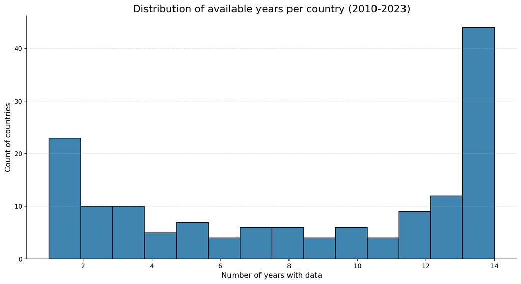

```python
# =============================================================
# Data-density check: how many years per country?
# =============================================================

import matplotlib.pyplot as plt
import seaborn as sns

if "master_df" not in globals():
    raise RuntimeError("Run the master-merge cell first — master_df not found.")

# 1️⃣  count **unique** years per country
year_counts = (
    master_df.groupby("country")["year"]
             .nunique()
             .sort_values(ascending=False)
)

print("— Data-density summary —")
print(year_counts.describe())

# 2️⃣  quick histogram of the distribution
plt.figure(figsize=(14, 7))
sns.histplot(year_counts, bins=14, color="#005b96")
plt.title("Distribution of available years per country (2010-2023)", fontsize=16)
plt.xlabel("Number of years with data", fontsize=12)
plt.ylabel("Count of countries", fontsize=12)
sns.despine()
plt.grid(axis="y", linestyle="--", alpha=0.4)
plt.show()
```

### **Step 2: Filter for Countries with Sufficient Data**

Based on the distribution above, we will now filter our master dataset to keep only the countries that have a sufficient number of data points for a reliable analysis. Let's see what countries will be dropped if we set the threeshold at 8.

```python
# =============================================================
# Full list of countries that would be dropped (< N years)
#   • Read-only: **does not** modify master_df
#   • Prints the entire list, no truncation
# =============================================================

min_years_required = 8        # ← adjust threshold here

if "master_df" not in globals():
    raise RuntimeError("Run the master-merge step first — master_df not found.")

# 1️⃣  Count distinct years of data per country
_year_counts = master_df.groupby("country")["year"].nunique()

# 2️⃣  Countries that fail the threshold
to_drop = (_year_counts[_year_counts < min_years_required]
           .sort_values())               # ascending: fewest years first

print(f"Countries that would be dropped (fewer than {min_years_required} years):")
print(f"  {len(to_drop)} countries total\n")

# 3️⃣  Print full list without truncation
with pd.option_context("display.max_rows", None, "display.max_colwidth", None):
    display(to_drop.to_frame(name="n_years"))
```

```
Countries that would be dropped (fewer than 8 years):
  65 countries total
```

| country | n_years |
| --- | --- |
| Sierra Leone | 1 |
| Lesotho | 1 |
| Liberia | 1 |
| Gambia, The | 1 |
| Malawi | 1 |
| Mauritania | 1 |
| Curacao | 1 |
| Nepal | 1 |
| Cameroon | 1 |
| Cabo Verde | 1 |
| Lebanon | 1 |
| Sudan | 1 |
| Kenya | 1 |
| Tajikistan | 1 |
| Timor-Leste | 1 |
| Tunisia | 1 |
| Vanuatu | 1 |
| Barbados | 1 |
| Bangladesh | 1 |
| Bahamas, The | 1 |
| Aruba | 1 |
| Antigua and Barbuda | 1 |
| Brunei Darussalam | 1 |
| North Macedonia | 2 |
| Maldives | 2 |
| Yemen, Rep. | 2 |
| Angola | 2 |
| Madagascar | 2 |
| Guyana | 2 |
| Fiji | 2 |
| Ethiopia | 2 |
| Burundi | 2 |
| Comoros | 2 |
| Lao PDR | 3 |
| Bahrain | 3 |
| Venezuela, RB | 3 |
| Benin | 3 |
| Bermuda | 3 |
| Samoa | 3 |
| Nigeria | 3 |
| Senegal | 3 |
| Eswatini | 3 |
| Nicaragua | 3 |
| Niger | 4 |
| Rwanda | 4 |
| Ghana | 4 |
| Burkina Faso | 4 |
| Mali | 4 |
| Cote d'Ivoire | 5 |
| Namibia | 5 |
| Myanmar | 5 |
| Jamaica | 5 |
| Suriname | 5 |
| Tanzania | 5 |
| Togo | 5 |
| Uzbekistan | 6 |
| Zimbabwe | 6 |
| Seychelles | 6 |
| Trinidad and Tobago | 6 |
| Zambia | 7 |
| Uganda | 7 |
| South Africa | 7 |
| Belize | 7 |
| Hong Kong SAR, China | 7 |
| Botswana | 7 |

```python
# --- Action: Filter the master DataFrame based on our new threshold ---

print("--- Filtering for Countries with Sufficient Data ---")

# Define the threshold you decided on
MINIMUM_YEARS = 8
print(f"Setting the minimum threshold to {MINIMUM_YEARS} years of data.")

# 1. First, recalculate the counts to ensure we have it in memory
country_year_counts = master_df['country'].value_counts()

# 2. Get the list of countries that meet this threshold
countries_to_keep = country_year_counts[country_year_counts >= MINIMUM_YEARS].index.tolist()

# 3. Filter the master dataframe
rows_before_filter = len(master_df)
master_df_filtered = master_df[master_df['country'].isin(countries_to_keep)].copy()
rows_after_filter = len(master_df_filtered)

# 4. Verification
print(f"\nOriginal number of unique countries: {master_df['country'].nunique()}")
print(f"Number of countries with at least {MINIMUM_YEARS} years of data: {len(countries_to_keep)}")
print(f"Number of countries removed: {master_df['country'].nunique() - len(countries_to_keep)}")

print(f"\nTotal rows before filtering: {rows_before_filter}")
print(f"Total rows after filtering: {rows_after_filter}")
print(f"Dropped {rows_before_filter - rows_after_filter} rows belonging to data-sparse countries.")
```

```
--- Filtering for Countries with Sufficient Data ---
Setting the minimum threshold to 8 years of data.

Original number of unique countries: 150
Number of countries with at least 8 years of data: 85
Number of countries removed: 65

Total rows before filtering: 1262
Total rows after filtering: 1068
Dropped 194 rows belonging to data-sparse countries.
```

#### **Step 3: Final Imputation — A Column-Specific Strategy**

- This is the final transformation for our dataset. Instead of applying a single blanket rule to all columns, we will use a more sophisticated, column-specific strategy to handle the remaining missing values (`NaNs`). This is because different indicators behave in different ways, and a tailored approach yields a more accurate and defensible final dataset.
- Our imputation logic is broken down by variable type:
  - **Structural & Governance Scores** (e.g., `political_stability_est`): These values change slowly over time. We will use a forward-fill then backward-fill method for each country to fill gaps using the last known valid observation.
  - **Gradual Socio-Economic Ratios** (e.g., `lpi_score`): For indicators that trend smoothly, we will use linear interpolation to fill small gaps, as it provides a more realistic estimate than simply carrying a static value forward.
  - **Economic "Level" Indicators** (e.g., `gdp_usd`, `population`): For variables that grow exponentially, we use a more advanced growth-rate imputation. We calculate the year-over-year growth rate, fill any gaps in that rate, and then rebuild the series. This correctly preserves the compounding nature of economic growth.
  - **Volatile Rates & Event Counts** (e.g., `inflation_pct`, `total_disorder_events`): For highly volatile data or for columns where `NaN` has a specific meaning (like "no ACLED coverage"), we will not impute any values for now. We will handle them separately after inspecting which countries we are missing the data for.
- This tailored approach ensures our final dataset is of the highest possible quality and integrity, ready for analysis.

```python
# -------------------------------------------------------------
# 1️⃣  Resolve duplicate column names BEFORE imputation
# -------------------------------------------------------------
dup_map = {
    # keep _y, drop _x  (swap if you prefer the reverse)
    "lpi_score_y": "lpi_score"
}

# drop the _x version
cols_to_drop = ["lpi_score_x"]
master_df_filtered = master_df_filtered.drop(columns=cols_to_drop, errors="ignore")

# rename the column we’re keeping
master_df_filtered = master_df_filtered.rename(columns=dup_map)
```

```python
# =============================================================
# Impute the remaining NaNs  ▸ “all-in-one” cell
#   • builds the schema *once* with every column we need
#   • applies the chosen method country-by-country
#   • finishes with one last safety interpolation
# =============================================================

# 1️⃣  Build the imputation schema  ────────────────────────────
impute_schema = {

    # forward-fill then backward-fill (good for slowly-moving governance scores)
    "ffill_bfill": [
        "political_stability_est",
        "rule_of_law_est",
        "control_of_corruption_est",
        "wage_usd",                          # <-- now included
    ],

    # linear interpolation ±3 years, then ffill/bfill
    "linear": [
        "lpi_score",
        "access_to_electricity_pct",
        "manufacturing_pct_gdp",
        "electric_power_consumption_kwh_pc",
        "gross_capital_formation_pct_gdp",
        "industry_pct_gdp",
    ],

    # multiplicative growth-rate fill (carry forward %Δ)
    "growth": [
        "gdp_usd",
        "population",
        "total_imports_usd",
    ],

    # leave NaNs as-is (true “missing” or 0-/inapplicable)
    "none": [
        "total_disorder_events",
        "inflation_pct",
        "gdp_growth_pct",
    ],

    # mining & ore series — just carry the last observation forward
    "ffill_only": [
        c for c in master_df_filtered.columns
        if c.endswith("_mine") or c.endswith("_ore")
    ],
}

# 2️⃣  Helper used by .transform()  ────────────────────────────
def impute_group(s, method):
    if method == "ffill_bfill":
        return s.ffill().bfill()

    if method == "linear":
        return s.interpolate(limit=3).ffill().bfill()

    if method == "growth":
        lvl = s
        pct = lvl.pct_change().ffill().bfill(limit=2)
        rebuilt = [lvl.iloc[0]]
        for r in pct.iloc[1:]:
            rebuilt.append(rebuilt[-1] * (1 + r))
        return pd.Series(rebuilt, index=lvl.index)

    if method == "ffill_only":
        return s.ffill()

    return s  # 'none' → untouched

# 3️⃣  Run the imputation  ────────────────────────────────────
master_imputed = master_df_filtered.copy()

for method, cols in impute_schema.items():
    for col in cols:
        if col not in master_imputed.columns:
            print(f"⚠️  Column '{col}' not found – skipping")
            continue
        master_imputed[col] = (
            master_imputed
              .groupby("country")[col]
              .transform(lambda g: impute_group(g, method))
        )

# 4️⃣  Final safety net for lpi_score (rare edge cases) ───────
master_imputed["lpi_score"] = (
    master_imputed
      .groupby("country")["lpi_score"]
      .transform(lambda s: s.interpolate(limit_direction="both"))
)

# 5️⃣  Quick audit  ───────────────────────────────────────────
print("\n✅  Imputation finished. Remaining NaNs per column:")
print(master_imputed.isna().sum().sort_values(ascending=False).head(10))
```

```
✅  Imputation finished. Remaining NaNs per column:
total_disorder_events                635
lpi_score                             17
electric_power_consumption_kwh_pc     17
manufacturing_pct_gdp                 14
inflation_pct                         12
gross_capital_formation_pct_gdp       10
wage_usd                               8
access_to_electricity_pct              0
graphite                               0
rule_of_law_est                        0
dtype: int64
```

#### **Diagnostic: Pinpointing Missing Data by Country**

- The imputation summary shows that a small number of `NaNs` remain in several key columns. This is expected, as imputation cannot create data for countries where none exists in the source.
- The following code cell will investigate this further. It will generate a "hit list" for each affected indicator, showing us exactly which countries are missing data. This will confirm that the issue is isolated to a handful of specific countries with sparse data reporting, rather than a widespread problem.

```python
# =============================================================
# Diagnostic Step: Identify Countries with Remaining NaNs (Expanded)
#   • Pinpoints which specific countries still have missing
#     values for all key indicators after imputation.
# =============================================================

# 1️⃣  List all columns we want to investigate
columns_to_investigate = [
    "lpi_score",
    "electric_power_consumption_kwh_pc",
    "manufacturing_pct_gdp",
    "inflation_pct",
    "gross_capital_formation_pct_gdp"
]

# A dictionary to hold our findings
countries_with_missing_data = {}

print("🔎 Investigating countries with remaining NaNs after imputation...\n")

# 2️⃣  Loop through each column and find associated countries
for col in columns_to_investigate:
    # Filter the DataFrame to rows where the current column is NaN
    missing_rows_df = master_imputed[master_imputed[col].isna()]

    # Get the unique country names from those rows
    unique_countries = missing_rows_df['country'].unique().tolist()

    # Store the list of countries in our dictionary
    countries_with_missing_data[col] = unique_countries

    # 3️⃣  Print a clean report for the column
    print(f"--- Report for: '{col}' ---")
    if unique_countries:
        print(f"Found {len(unique_countries)} countries with missing data:")
        # Nicely print the list of countries
        for country in sorted(unique_countries):
            print(f"  • {country}")
    else:
        print("  ✅ No countries with missing data found.")
    print("-" * (len(col) + 20) + "\n")
```

```
🔎 Investigating countries with remaining NaNs after imputation...

--- Report for: 'lpi_score' ---
Found 2 countries with missing data:
  • Macao SAR, China
  • West Bank and Gaza
-----------------------------

--- Report for: 'electric_power_consumption_kwh_pc' ---
Found 2 countries with missing data:
  • Macao SAR, China
  • West Bank and Gaza
-----------------------------------------------------

--- Report for: 'manufacturing_pct_gdp' ---
Found 1 countries with missing data:
  • Bulgaria
-----------------------------------------

--- Report for: 'inflation_pct' ---
Found 1 countries with missing data:
  • Argentina
---------------------------------

--- Report for: 'gross_capital_formation_pct_gdp' ---
Found 1 countries with missing data:
  • Qatar
---------------------------------------------------
```

#### **Step 5: Handling Final Missing Values**

```python
# ------------------------------------------------------------
# 0️⃣  Countries we decided to exclude
#     (based on the diagnostic output)
# ------------------------------------------------------------
drop_ctys = ["Macao SAR, China",
             "West Bank and Gaza",
             "Bulgaria",
             "Argentina",
             "Qatar"]

# ------------------------------------------------------------
# 1️⃣  Remove those countries, keep the rest intact
# ------------------------------------------------------------
model_ready_df = master_imputed[~master_imputed["country"].isin(drop_ctys)].copy()

print(f"Kept {model_ready_df['country'].nunique()} countries "
      f"({model_ready_df.shape[0]} rows).")

# ------------------------------------------------------------
# 2️⃣  Optional: verify we’re now truly NaN-free
# ------------------------------------------------------------
# -------------------------------------------------------------
# Final null check — show NaNs *per column*
# -------------------------------------------------------------
null_by_col = (
    model_ready_df
      .isna()
      .sum()                       # count NaNs per column
      .sort_values(ascending=False)
)

if null_by_col.sum() == 0:
    print("✅  No remaining NaNs. Dataset is modeling-ready.")
else:
    print("✅  Imputation finished. Remaining NaNs per column:")
    print(null_by_col[null_by_col > 0])          # only columns that still have NaNs
```

```
Kept 80 countries (1015 rows).
✅  Imputation finished. Remaining NaNs per column:
total_disorder_events    607
dtype: int64
```

```python
# =============================================================
# Diagnostic: Identify Countries with Missing ACLED Data
#   • Pinpoints which countries in our current dataset lack
#     coverage from the ACLED conflict database.
# =============================================================

# 1️⃣  Filter the DataFrame to only the rows with missing disorder data
missing_disorder_df = model_ready_df[model_ready_df['total_disorder_events'].isna()]

# 2️⃣  Get the unique list of countries from that filtered data
countries_missing_acled_data = sorted(missing_disorder_df['country'].unique().tolist())

# 3️⃣  Print a clean report
total_countries_in_set = model_ready_df['country'].nunique()
print(f"Found {len(countries_missing_acled_data)} out of {total_countries_in_set} countries with missing ACLED conflict data:\n")

# Print the list in a readable format
for country in countries_missing_acled_data:
    print(f"  • {country}")
```

```
Found 73 out of 80 countries with missing ACLED conflict data:

  • Albania
  • Armenia
  • Australia
  • Austria
  • Azerbaijan
  • Belgium
  • Bolivia
  • Bosnia and Herzegovina
  • Brazil
  • Canada
  • Chile
  • China
  • Colombia
  • Costa Rica
  • Croatia
  • Cyprus
  • Czechia
  • Denmark
  • Dominican Republic
  • Ecuador
  • El Salvador
  • Estonia
  • Finland
  • France
  • Georgia
  • Germany
  • Greece
  • Guatemala
  • Honduras
  • Hungary
  • Iceland
  • India
  • Indonesia
  • Ireland
  • Israel
  • Italy
  • Japan
  • Kazakhstan
```

[output cut: 20 more lines]

```
  • Portugal
  • Romania
  • Russian Federation
  • Serbia
  • Singapore
  • Slovak Republic
  • Slovenia
  • Spain
  • Sweden
  • Switzerland
  • Turkiye
  • Ukraine
  • United Kingdom
  • United States
  • Uruguay
```

#### **Final Data Treatment: Engineering the ACLED Conflict Feature**

```python
# =============================================================
# Final ACLED treatment ─ flag coverage, zero-fill the rest
# =============================================================

# 1️⃣  Boolean flag: did ACLED actually cover this country-year?
model_ready_df["acled_covered"] = model_ready_df["total_disorder_events"].notna()

# 2️⃣  Replace the remaining NaNs with 0
#     (keeps dtype nullable Int64 so NaNs could be restored if ever needed)
model_ready_df["total_disorder_events"] = (
    model_ready_df["total_disorder_events"]
      .fillna(0)
      .astype("Int64")
)

# 3️⃣  Quick sanity check
print("✅  ACLED post-processing complete")
print("   • NaNs left in total_disorder_events:",
      model_ready_df["total_disorder_events"].isna().sum())

# Show the first few rows for a visual spot-check
display(
    model_ready_df[["country", "year",
                    "total_disorder_events", "acled_covered"]]
      .head(10)
)
```

```
✅  ACLED post-processing complete
   • NaNs left in total_disorder_events: 0
```

|  | country | year | total_disorder_events | acled_covered |
| --- | --- | --- | --- | --- |
| 0 | Albania | 2010 | 0 | False |
| 1 | Albania | 2015 | 0 | False |
| 2 | Albania | 2016 | 0 | False |
| 3 | Albania | 2017 | 0 | False |
| 4 | Albania | 2018 | 239 | True |
| 5 | Albania | 2019 | 341 | True |
| 6 | Albania | 2020 | 223 | True |
| 7 | Albania | 2021 | 170 | True |
| 23 | Armenia | 2010 | 0 | False |
| 24 | Armenia | 2011 | 0 | False |

## **Final Pre-Modeling Checklist**

#### **Final Review of Data Structure and Types**

```python
# =============================================================
# Checklist Step 1: Final Structure and Type Review
# =============================================================
print("--- Final Data Structure and Types ---")
model_ready_df.info()
```

```
--- Final Data Structure and Types ---
<class 'pandas.core.frame.DataFrame'>
Index: 1015 entries, 0 to 1238
Data columns (total 25 columns):
 #   Column                             Non-Null Count  Dtype
---  ------                             --------------  -----
 0   country                            1015 non-null   object
 1   year                               1015 non-null   Int64
 2   gdp_usd                            1015 non-null   float64
 3   gdp_growth_pct                     1015 non-null   float64
 4   population                         1015 non-null   float64
 5   fdi_net_inflows_pct_gdp            1015 non-null   float64
 6   manufacturing_pct_gdp              1015 non-null   float64
 7   access_to_electricity_pct          1015 non-null   float64
 8   electric_power_consumption_kwh_pc  1015 non-null   float64
```

[output cut: 18 more lines]

#### **Descriptive Statistics Sanity Check**

```python
# =============================================================
# Checklist Step 2: Descriptive Statistics Sanity Check
# =============================================================
print("\n--- Final Descriptive Statistics ---")
# Using .T to transpose the output for better readability
display(model_ready_df.describe().T)
```

```
--- Final Descriptive Statistics ---
```

|  | count | mean | std | min | 25% | 50% | 75% | max |
| --- | --- | --- | --- | --- | --- | --- | --- | --- |
| year | 1015.0 | 2016.380296 | 3.92172 | 2010.0 | 2013.0 | 2016.0 | 2020.0 | 2023.0 |
| gdp_usd | 1015.0 | 980636615212.934937 | 2804863988649.442383 | 4054730077.57718 | 46589833347.141052 | 221985621537.5 | 598672532690.494507 | 27720709000000.003906 |
| gdp_growth_pct | 1015.0 | 2.97985 | 3.788866 | -17.82123 | 1.473645 | 2.975198 | 4.988908 | 24.61557 |
| population | 1015.0 | 65073117.380788 | 200642978.32147 | 318041.0 | 4787253.5 | 10536632.0 | 46883847.0 | 1438069596.0 |
| fdi_net_inflows_pct_gdp | 1015.0 | 7.010528 | 38.483128 | -440.130675 | 1.418249 | 2.809148 | 4.806302 | 452.22104 |
| manufacturing_pct_gdp | 1015.0 | 14.173551 | 5.649289 | 3.531508 | 10.34535 | 13.320763 | 17.693026 | 37.146829 |
| access_to_electricity_pct | 1015.0 | 98.500493 | 5.181774 | 31.1 | 99.6 | 100.0 | 100.0 | 100.0 |
| electric_power_consumption_kwh_pc | 1015.0 | 5351.577912 | 5999.831023 | 157.026621 | 2031.30935 | 4028.618409 | 6686.486203 | 54799.174708 |
| gross_capital_formation_pct_gdp | 1015.0 | 22.51545 | 5.259329 | 10.970463 | 19.401657 | 22.034538 | 24.75402 | 53.22203 |
| inflation_pct | 1015.0 | 3.798036 | 5.012495 | -2.096998 | 1.223878 | 2.668248 | 4.878178 | 72.308836 |
| total_imports_usd | 1015.0 | 403844031.632711 | 1348277495.048109 | 3412.0 | 3059114.07 | 23186036.0 | 187005728.537 | 19376702357.0 |
| wage_usd | 1015.0 | 1596.142461 | 1916.369217 | 2.630496 | 298.11197 | 585.788052 | 2532.61011 | 8460.399351 |
| lpi_score | 1015.0 | 3.225975 | 0.521685 | 2.15593 | 2.780254 | 3.18 | 3.7 | 4.225967 |
| industry_pct_gdp | 1015.0 | 25.858025 | 7.456112 | 9.972877 | 20.587859 | 25.20554 | 30.028295 | 61.732844 |
| cobalt,_mine | 1015.0 | 374.716256 | 1402.006475 | 0.0 | 0.0 | 0.0 | 0.0 | 10237.0 |
| graphite | 1015.0 | 13857.93399 | 104359.568196 | 0.0 | 0.0 | 0.0 | 0.0 | 1800000.0 |
| lithium_minerals | 1015.0 | 14549.364532 | 131947.077647 | 0.0 | 0.0 | 0.0 | 0.0 | 2021498.0 |
| manganese_ore | 1015.0 | 346966.960591 | 1690468.676438 | 0.0 | 0.0 | 0.0 | 0.0 | 20000000.0 |
| nickel,_mine | 1015.0 | 24263.083744 | 106378.802113 | 0.0 | 0.0 | 0.0 | 0.0 | 1579000.0 |
| political_stability_est | 1015.0 | 0.204241 | 0.78824 | -2.810035 | -0.384315 | 0.337448 | 0.861701 | 1.619806 |
| control_of_corruption_est | 1015.0 | 0.391437 | 1.040373 | -1.3235 | -0.50807 | 0.210814 | 1.338688 | 2.402638 |
| rule_of_law_est | 1015.0 | 0.466882 | 0.951886 | -1.301404 | -0.365422 | 0.427085 | 1.343412 | 2.124762 |
| total_disorder_events | 1015.0 | 818.380296 | 2615.69369 | 0.0 | 0.0 | 0.0 | 340.0 | 23311.0 |

#### **Visual Distribution Check**

```
--- Visual Check of Key Feature Distributions ---
```

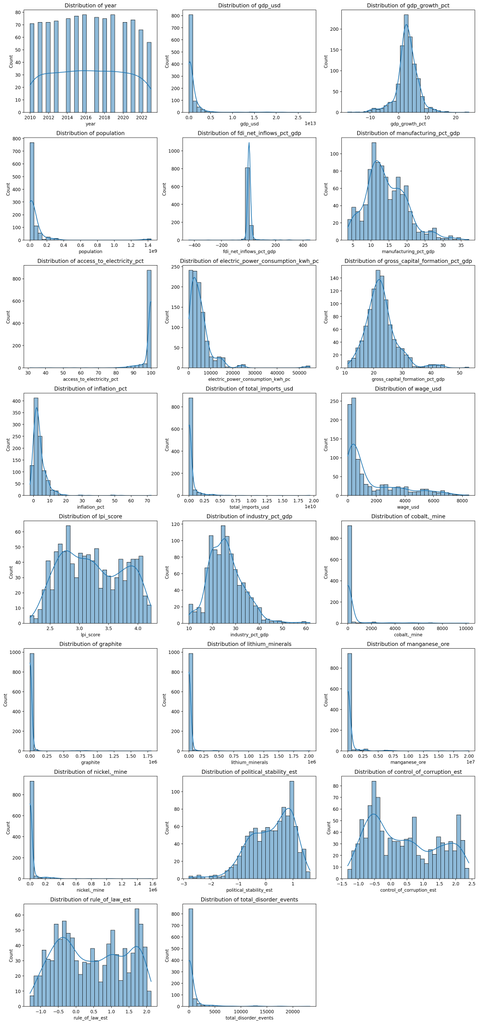

```python
# =============================================================
# Checklist Step 3: Visual Distribution Check
# =============================================================
# Select only the numeric columns for plotting
numeric_cols = model_ready_df.select_dtypes(include=['number']).columns

# Determine the number of rows and columns for the subplot grid
n_cols = 3
n_rows = (len(numeric_cols) - 1) // n_cols + 1

fig, axes = plt.subplots(n_rows, n_cols, figsize=(15, n_rows * 4))
axes = axes.flatten() # Flatten the grid to a 1D array for easy iteration

print("\n--- Visual Check of Key Feature Distributions ---")

for i, col in enumerate(numeric_cols):
    sns.histplot(model_ready_df[col], kde=True, ax=axes[i], bins=30)
    axes[i].set_title(f'Distribution of {col}')
    axes[i].grid(False) # As per your preference for no grid lines

# Hide any unused subplots
for j in range(i + 1, len(axes)):
    axes[j].set_visible(False)

plt.tight_layout()
plt.show()
```

#### **Saving Final, Clean Dataset**

```python
# =============================================================
# Checklist Step 4: Save the Modeling-Ready Data
# =============================================================

# We recommend Parquet for its efficiency and type preservation, but CSV is also great.
output_filename_parquet = "model_ready_data.parquet"
output_filename_csv = "model_ready_data.csv"

# Save to Parquet
model_ready_df.to_parquet(output_filename_parquet)

# Save to CSV (index=False prevents pandas from writing row numbers as a column)
model_ready_df.to_csv(output_filename_csv, index=False)

print(f"\n✅  Successfully saved final dataset to:")
print(f"    • {output_filename_parquet}")
print(f"    • {output_filename_csv}")
```

```
✅  Successfully saved final dataset to:
    • model_ready_data.parquet
    • model_ready_data.csv
```